# MiningNotebook

## title: "Housing Prices Predictions"

## Problem

The problem our project aims to solve revolves around accurately predicting house prices based on various features provided in the dataset. This predictive model helps stakeholders, such as real estate agents, buyers, and sellers, in estimating the price of a house given its characteristics.

## Goal of Collecting this Dataset

This dataset provides key features for predicting house prices, including area, bedrooms, bathrooms, stories, amenities like air conditioning and parking, and information on furnishing status. It enables analysis and modelling to understand the factors impacting house datas and develop accurate predictions in real estate markets using both classification and clustering techniques for better understanding and to get the most results out of it.

## Source of the Dataset

The dataset was sourced from the kaggle website in this URL : https://www.kaggle.com/datasets/harishkumardatalab/housing-price-prediction

## General Information

- Number of Attributes: 13
- Number of Objects: 545
- Type of Attributes: Numeric, Symmetric Binary, Ordinal.
- Classes names: Price.

## About Dataset

This dataset provides comprehensive information for house price prediction, with 13 column names:

- Price: The price of the house.
- Area: The total area of the house in square feet.
- Bedrooms: The number of bedrooms in the house.
- Bathrooms: The number of bathrooms in the house.
- Stories: The number of stories in the house.
- Mainroad: Whether the house is connected to the main road (Yes/No).
- Guestroom: Whether the house has a guest room (Yes/No).
- Basement: Whether the house has a basement (Yes/No).
- Hot water heating: Whether the house has a hot water heating system (Yes/No).
- Airconditioning: Whether the house has an air conditioning system (Yes/No).
- Parking: The number of parking spaces available within the house.
- Prefarea: Whether the house is located in a preferred area (Yes/No).
- Furnishing status: The furnishing status of the house (Fully Furnished, Semi-Furnished, Unfurnished).

```r
data <- read.csv("Dataset/Housing.csv")
data
```

A data.frame: 545 × 13

| price <int> | area <int> | bedrooms <int> | bathrooms <int> | stories <int> | mainroad <chr> | guestroom <chr> | basement <chr> | hotwaterheating <chr> | airconditioning <chr> | parking <int> | prefarea <chr> | furnishingstatus <chr> |
| --- | --- | --- | --- | --- | --- | --- | --- | --- | --- | --- | --- | --- |
| 13300000 | 7420 | 4 | 2 | 3 | yes | no | no | no | yes | 2 | yes | furnished |
| 12250000 | 8960 | 4 | 4 | 4 | yes | no | no | no | yes | 3 | no | furnished |
| 12250000 | 9960 | 3 | 2 | 2 | yes | no | yes | no | no | 2 | yes | semi-furnished |
| 12215000 | 7500 | 4 | 2 | 2 | yes | no | yes | no | yes | 3 | yes | furnished |
| 11410000 | 7420 | 4 | 1 | 2 | yes | yes | yes | no | yes | 2 | no | furnished |
| 10850000 | 7500 | 3 | 3 | 1 | yes | no | yes | no | yes | 2 | yes | semi-furnished |
| 10150000 | 8580 | 4 | 3 | 4 | yes | no | no | no | yes | 2 | yes | semi-furnished |
| 10150000 | 16200 | 5 | 3 | 2 | yes | no | no | no | no | 0 | no | unfurnished |
| 9870000 | 8100 | 4 | 1 | 2 | yes | yes | yes | no | yes | 2 | yes | furnished |
| 9800000 | 5750 | 3 | 2 | 4 | yes | yes | no | no | yes | 1 | yes | unfurnished |
| 9800000 | 13200 | 3 | 1 | 2 | yes | no | yes | no | yes | 2 | yes | furnished |
| 9681000 | 6000 | 4 | 3 | 2 | yes | yes | yes | yes | no | 2 | no | semi-furnished |
| 9310000 | 6550 | 4 | 2 | 2 | yes | no | no | no | yes | 1 | yes | semi-furnished |
| 9240000 | 3500 | 4 | 2 | 2 | yes | no | no | yes | no | 2 | no | furnished |
| 9240000 | 7800 | 3 | 2 | 2 | yes | no | no | no | no | 0 | yes | semi-furnished |
| 9100000 | 6000 | 4 | 1 | 2 | yes | no | yes | no | no | 2 | no | semi-furnished |
| 9100000 | 6600 | 4 | 2 | 2 | yes | yes | yes | no | yes | 1 | yes | unfurnished |
| 8960000 | 8500 | 3 | 2 | 4 | yes | no | no | no | yes | 2 | no | furnished |
| 8890000 | 4600 | 3 | 2 | 2 | yes | yes | no | no | yes | 2 | no | furnished |
| 8855000 | 6420 | 3 | 2 | 2 | yes | no | no | no | yes | 1 | yes | semi-furnished |
| 8750000 | 4320 | 3 | 1 | 2 | yes | no | yes | yes | no | 2 | no | semi-furnished |
| 8680000 | 7155 | 3 | 2 | 1 | yes | yes | yes | no | yes | 2 | no | unfurnished |
| 8645000 | 8050 | 3 | 1 | 1 | yes | yes | yes | no | yes | 1 | no | furnished |
| 8645000 | 4560 | 3 | 2 | 2 | yes | yes | yes | no | yes | 1 | no | furnished |
| 8575000 | 8800 | 3 | 2 | 2 | yes | no | no | no | yes | 2 | no | furnished |
| 8540000 | 6540 | 4 | 2 | 2 | yes | yes | yes | no | yes | 2 | yes | furnished |
| 8463000 | 6000 | 3 | 2 | 4 | yes | yes | yes | no | yes | 0 | yes | semi-furnished |
| 8400000 | 8875 | 3 | 1 | 1 | yes | no | no | no | no | 1 | no | semi-furnished |
| 8400000 | 7950 | 5 | 2 | 2 | yes | no | yes | yes | no | 2 | no | unfurnished |
| 8400000 | 5500 | 4 | 2 | 2 | yes | no | yes | no | yes | 1 | yes | semi-furnished |
| ⋮ | ⋮ | ⋮ | ⋮ | ⋮ | ⋮ | ⋮ | ⋮ | ⋮ | ⋮ | ⋮ | ⋮ | ⋮ |
| 2450000 | 3210 | 3 | 1 | 2 | yes | no | yes | no | no | 0 | no | unfurnished |
| 2450000 | 3240 | 2 | 1 | 1 | no | yes | no | no | no | 1 | no | unfurnished |
| 2450000 | 3000 | 2 | 1 | 1 | yes | no | no | no | no | 1 | no | unfurnished |
| 2450000 | 3500 | 2 | 1 | 1 | yes | yes | no | no | no | 0 | no | unfurnished |
| 2450000 | 4840 | 2 | 1 | 2 | yes | no | no | no | no | 0 | no | unfurnished |
| 2450000 | 7700 | 2 | 1 | 1 | yes | no | no | no | no | 0 | no | unfurnished |
| 2408000 | 3635 | 2 | 1 | 1 | no | no | no | no | no | 0 | no | unfurnished |
| 2380000 | 2475 | 3 | 1 | 2 | yes | no | no | no | no | 0 | no | furnished |
| 2380000 | 2787 | 4 | 2 | 2 | yes | no | no | no | no | 0 | no | furnished |
| 2380000 | 3264 | 2 | 1 | 1 | yes | no | no | no | no | 0 | no | unfurnished |
| 2345000 | 3640 | 2 | 1 | 1 | yes | no | no | no | no | 0 | no | unfurnished |
| 2310000 | 3180 | 2 | 1 | 1 | yes | no | no | no | no | 0 | no | unfurnished |
| 2275000 | 1836 | 2 | 1 | 1 | no | no | yes | no | no | 0 | no | semi-furnished |
| 2275000 | 3970 | 1 | 1 | 1 | no | no | no | no | no | 0 | no | unfurnished |
| 2275000 | 3970 | 3 | 1 | 2 | yes | no | yes | no | no | 0 | no | unfurnished |
| 2240000 | 1950 | 3 | 1 | 1 | no | no | no | yes | no | 0 | no | unfurnished |
| 2233000 | 5300 | 3 | 1 | 1 | no | no | no | no | yes | 0 | yes | unfurnished |
| 2135000 | 3000 | 2 | 1 | 1 | no | no | no | no | no | 0 | no | unfurnished |
| 2100000 | 2400 | 3 | 1 | 2 | yes | no | no | no | no | 0 | no | unfurnished |
| 2100000 | 3000 | 4 | 1 | 2 | yes | no | no | no | no | 0 | no | unfurnished |
| 2100000 | 3360 | 2 | 1 | 1 | yes | no | no | no | no | 1 | no | unfurnished |
| 1960000 | 3420 | 5 | 1 | 2 | no | no | no | no | no | 0 | no | unfurnished |
| 1890000 | 1700 | 3 | 1 | 2 | yes | no | no | no | no | 0 | no | unfurnished |
| 1890000 | 3649 | 2 | 1 | 1 | yes | no | no | no | no | 0 | no | unfurnished |
| 1855000 | 2990 | 2 | 1 | 1 | no | no | no | no | no | 1 | no | unfurnished |
| 1820000 | 3000 | 2 | 1 | 1 | yes | no | yes | no | no | 2 | no | unfurnished |
| 1767150 | 2400 | 3 | 1 | 1 | no | no | no | no | no | 0 | no | semi-furnished |
| 1750000 | 3620 | 2 | 1 | 1 | yes | no | no | no | no | 0 | no | unfurnished |
| 1750000 | 2910 | 3 | 1 | 1 | no | no | no | no | no | 0 | no | furnished |
| 1750000 | 3850 | 3 | 1 | 2 | yes | no | no | no | no | 0 | no | unfurnished |

```r
# Summary of the dataset
summary(data)
```

```
     price               area          bedrooms       bathrooms
 Min.   : 1750000   Min.   : 1650   Min.   :1.000   Min.   :1.000
 1st Qu.: 3430000   1st Qu.: 3600   1st Qu.:2.000   1st Qu.:1.000
 Median : 4340000   Median : 4600   Median :3.000   Median :1.000
 Mean   : 4766729   Mean   : 5151   Mean   :2.965   Mean   :1.286
 3rd Qu.: 5740000   3rd Qu.: 6360   3rd Qu.:3.000   3rd Qu.:2.000
 Max.   :13300000   Max.   :16200   Max.   :6.000   Max.   :4.000
    stories        mainroad          guestroom           basement
 Min.   :1.000   Length:545         Length:545         Length:545
 1st Qu.:1.000   Class :character   Class :character   Class :character
 Median :2.000   Mode  :character   Mode  :character   Mode  :character
 Mean   :1.806
 3rd Qu.:2.000
 Max.   :4.000
 hotwaterheating    airconditioning       parking         prefarea
 Length:545         Length:545         Min.   :0.0000   Length:545
 Class :character   Class :character   1st Qu.:0.0000   Class :character
 Mode  :character   Mode  :character   Median :0.0000   Mode  :character
                                       Mean   :0.6936
                                       3rd Qu.:1.0000
                                       Max.   :3.0000
 furnishingstatus
 Length:545
 Class :character
 Mode  :character
```

# Data Visualization

## 1. Scatter plot:

A scatter plot is a powerful visualization tool used in data analysis to explore the relationship between two numerical attributes. It presents data points as individual dots on a two-dimensional plane, with one attribute represented on the x-axis and the other on the y-axis. By plotting data in this manner, a scatter plot allows us to visually assess and understand patterns, trends, and correlations between the two attributes.

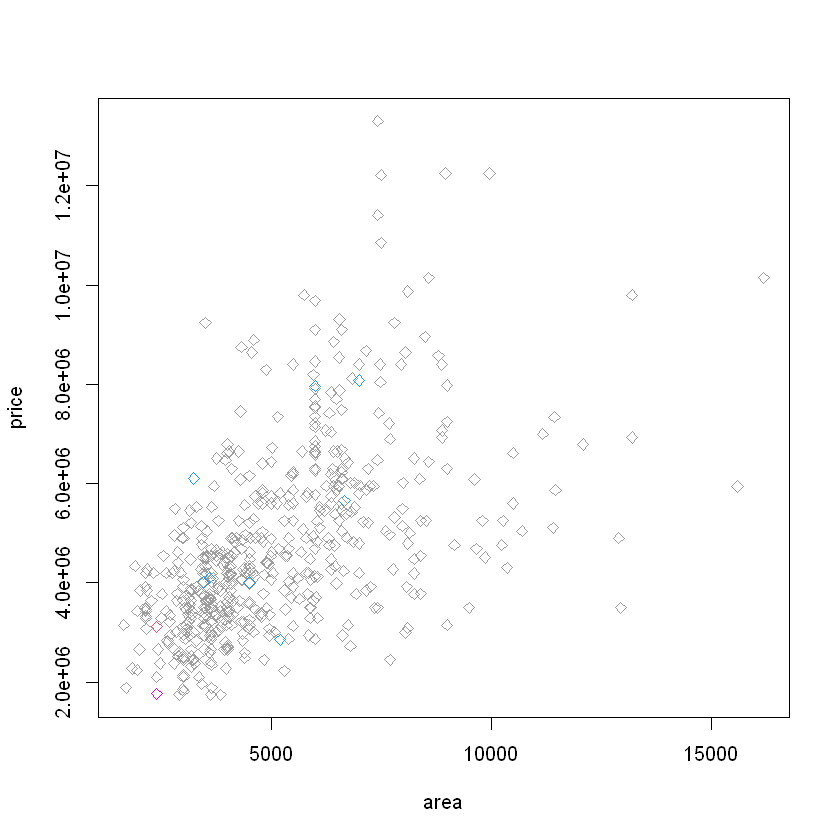

```r
#Scatter plot
with(data, plot(area, price, col = price, pch = 23))
```

## 2. Histogram:

A histogram is a graphical representation commonly used in statistics and data analysis to visualize the distribution of a single numerical variable. It divides the data into intervals, or "bins," and displays the count of data points falling into each bin as vertical bars. The height of each bar represents how many data points are in that bin, giving a clear and visual representation of the data's distribution. Histograms are valuable for understanding the dataset. They help identify patterns like normal distributions, skewness, or multimodal behavior, making them a fundamental tool for data exploration and analysis.

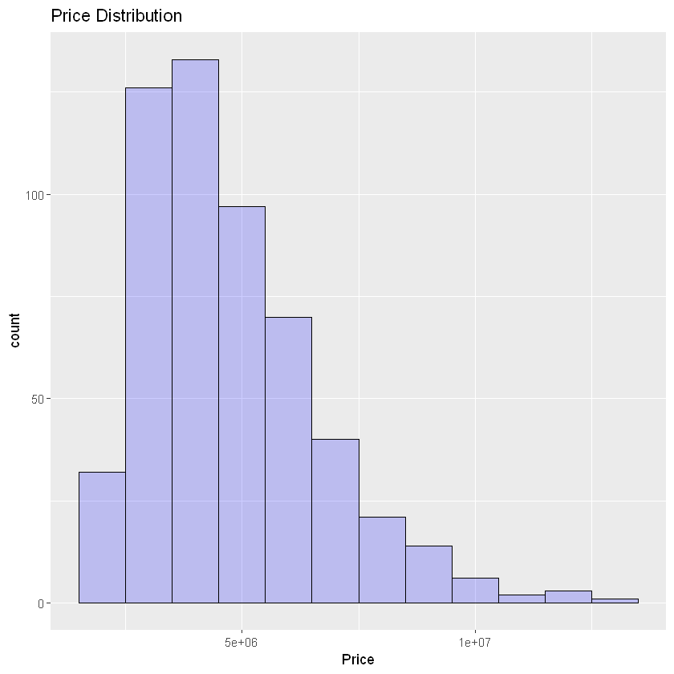

```r
install.packages("ggplot2")
library(ggplot2)
#Histogram
ggplot(data, aes(x = price)) +
  geom_histogram(binwidth = 1000000, fill = "blue", color = "black", alpha = 0.2) +
  labs(title = "Price Distribution", x = "Price")
```

## 3. Bar Plot

A bar plot, also known as a bar chart or bar graph, is a widely used data visualization tool that displays categorical data using rectangular bars. Each bar represents a specific category or group of an attribute, and the height (or length) of the bar corresponds to the value or frequency of that category.

Bar plots provide a clear and easy-to-understand representation of data, making it simple to identify patterns, trends, and variations within the attribute and the dataset. Bar plots are commonly used for displaying counts, frequencies, percentages, or other measures associated with distinct categories.

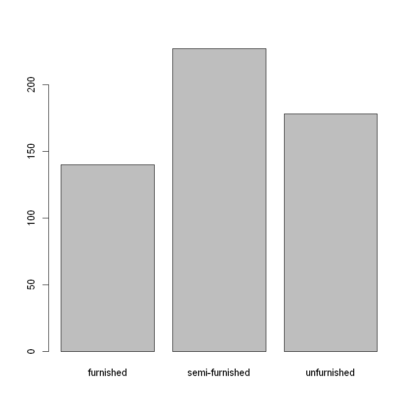

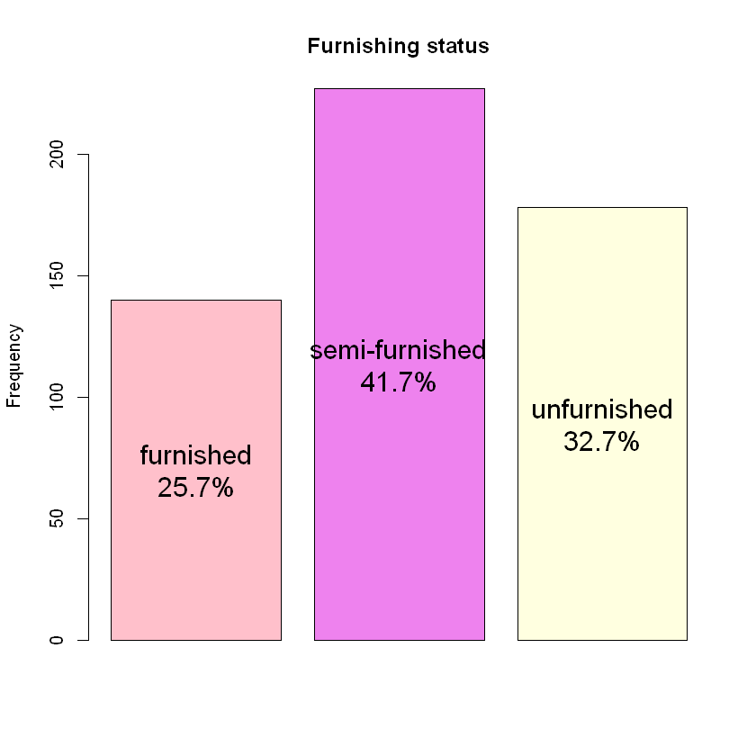

```r
#Bar Plot
#install.packages("dplyr")
library(dplyr)
data$furnishingstatus %>% table() %>% barplot()
# add colors and percentages
tab <- data$furnishingstatus %>% table()
precentages <- tab %>% prop.table() %>% round(3) * 100
txt <- paste0(names(tab), '\n', precentages, '%')
bb <- data$furnishingstatus %>% table() %>% barplot(axisnames=F, main='Furnishing status', ylab='Frequency',col=c('pink', 'violet', 'lightyellow'))
text(bb, tab/2, labels=txt, cex=1.5)
```

we made the barplot for the furnishing status which shows the distribution on its three possible values (furnished, semi-furnished, unfurnished) on the whole dataset, the semi-furnished is the most prevalant among the 3 values having a percentage of 41.7% which is almost half of the values selected. but the other two are not too low they are quite close to each other actually which shows that the values are spread out variously.

## Data Pre-processing:

we performed some data preprocessing methods which are:

- **Data cleaning:** can be applied to filling in missing values, remove noise, resolving inconsistencies, identifying and removing outliers in the data.
- **Data transformations:** such as normalization and discretization, may be applied. For example, normalization may improve the accuracy and efficiency of mining algorithms involving distance measurements.
- **Feature Selection:** can be applied to select a sample that contains clean data(non-redundant, and relevant features) from the original data set.

## 1. Data Cleaning

1.1 we checked if we have missing values or not, and we concluded that we had no missing values:

```r
# Check missing values
missing_values <- colSums(is.na(data))
missing_values
```

**price**

0

**area**

0

**bedrooms**

0

**bathrooms**

0

**stories**

0

**mainroad**

0

**guestroom**

0

**basement**

0

**hotwaterheating**

0

**airconditioning**

0

**parking**

0

**prefarea**

0

**furnishingstatus**

0

1.2 Data Cleaning and Noise Removal (it removes duplicates if any), and we noticed that we had no redundant data:

```r
data <- unique(data)
head(data)
```

A data.frame: 6 × 13

|  | price <int> | area <int> | bedrooms <int> | bathrooms <int> | stories <int> | mainroad <chr> | guestroom <chr> | basement <chr> | hotwaterheating <chr> | airconditioning <chr> | parking <int> | prefarea <chr> | furnishingstatus <chr> |
| --- | --- | --- | --- | --- | --- | --- | --- | --- | --- | --- | --- | --- | --- |
| 1 | 13300000 | 7420 | 4 | 2 | 3 | yes | no | no | no | yes | 2 | yes | furnished |
| 2 | 12250000 | 8960 | 4 | 4 | 4 | yes | no | no | no | yes | 3 | no | furnished |
| 3 | 12250000 | 9960 | 3 | 2 | 2 | yes | no | yes | no | no | 2 | yes | semi-furnished |
| 4 | 12215000 | 7500 | 4 | 2 | 2 | yes | no | yes | no | yes | 3 | yes | furnished |
| 5 | 11410000 | 7420 | 4 | 1 | 2 | yes | yes | yes | no | yes | 2 | no | furnished |
| 6 | 10850000 | 7500 | 3 | 3 | 1 | yes | no | yes | no | yes | 2 | yes | semi-furnished |

1.3 Detecting and removing outliers:

```
Number of outliers for Price: 15
```

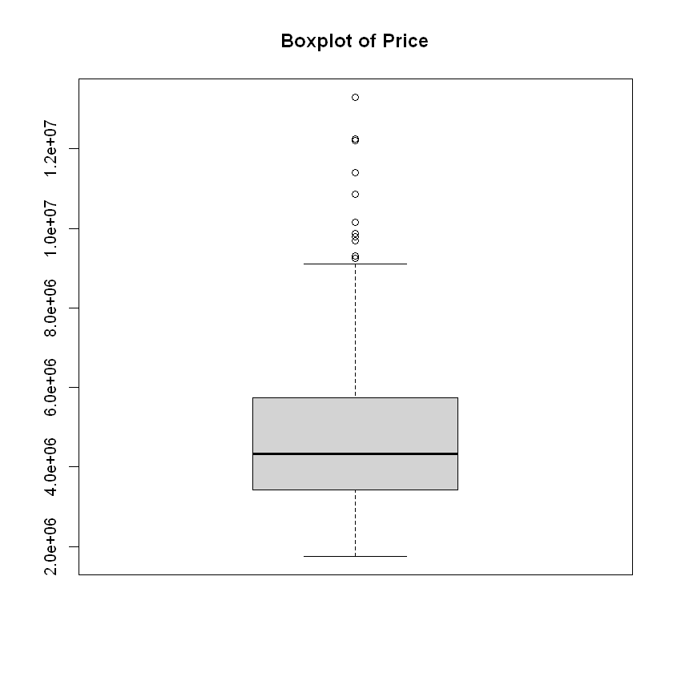

```
Number of outliers for Area: 12
```

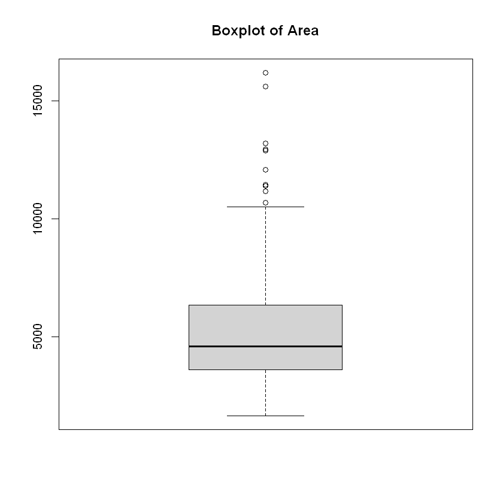

```
Number of outliers for Bedrooms: 12
```

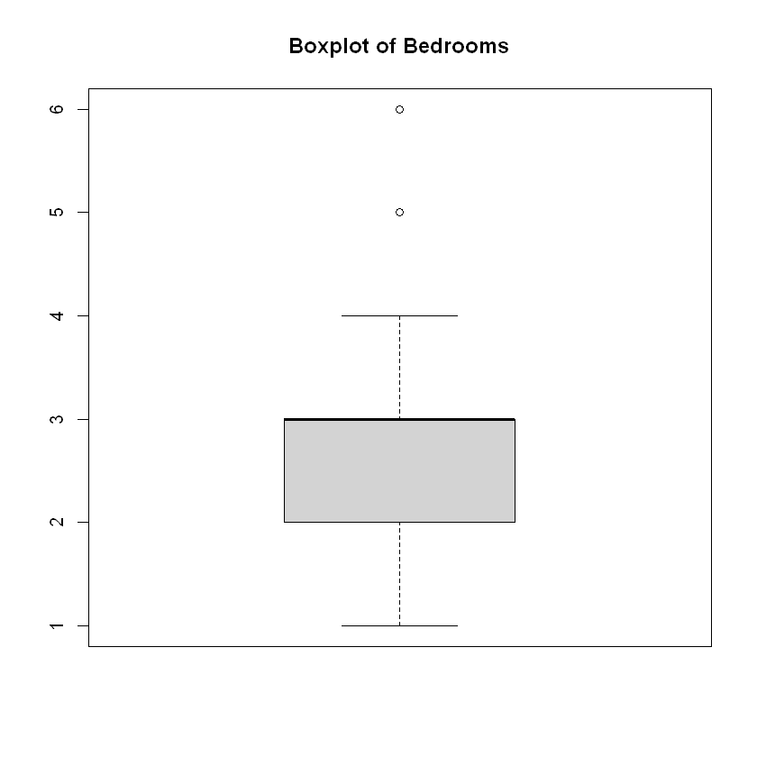

```
Number of outliers for Bathrooms: 1
```

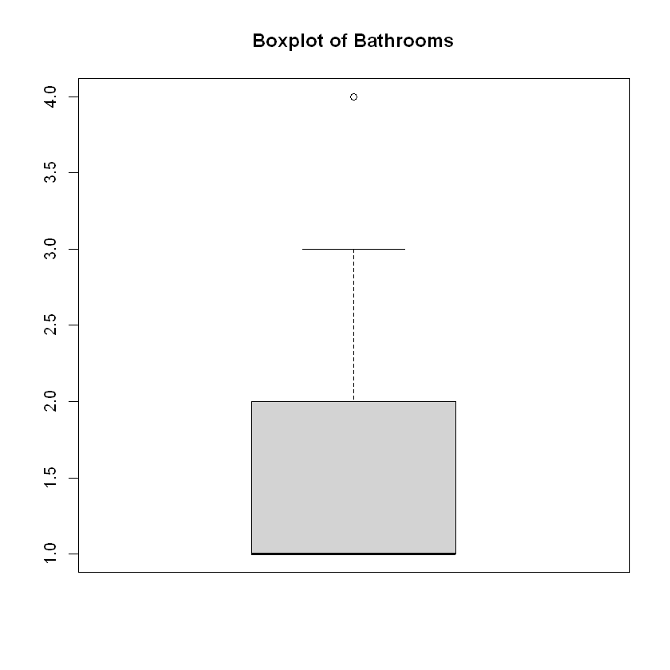

```
Number of outliers for Stories: 41
```

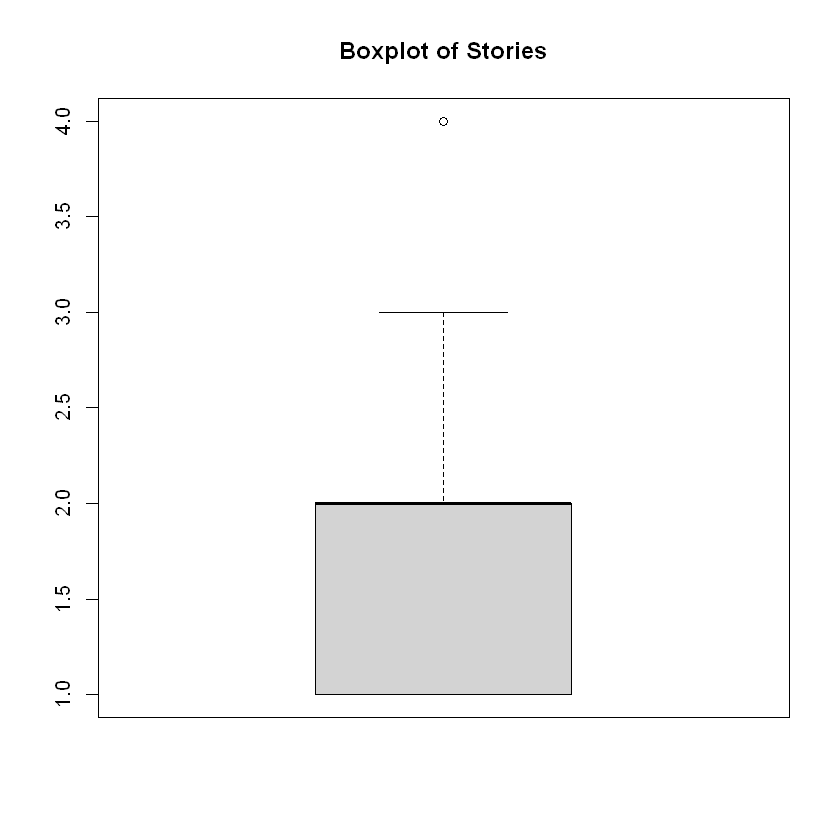

```
Number of outliers for Parking: 12
```

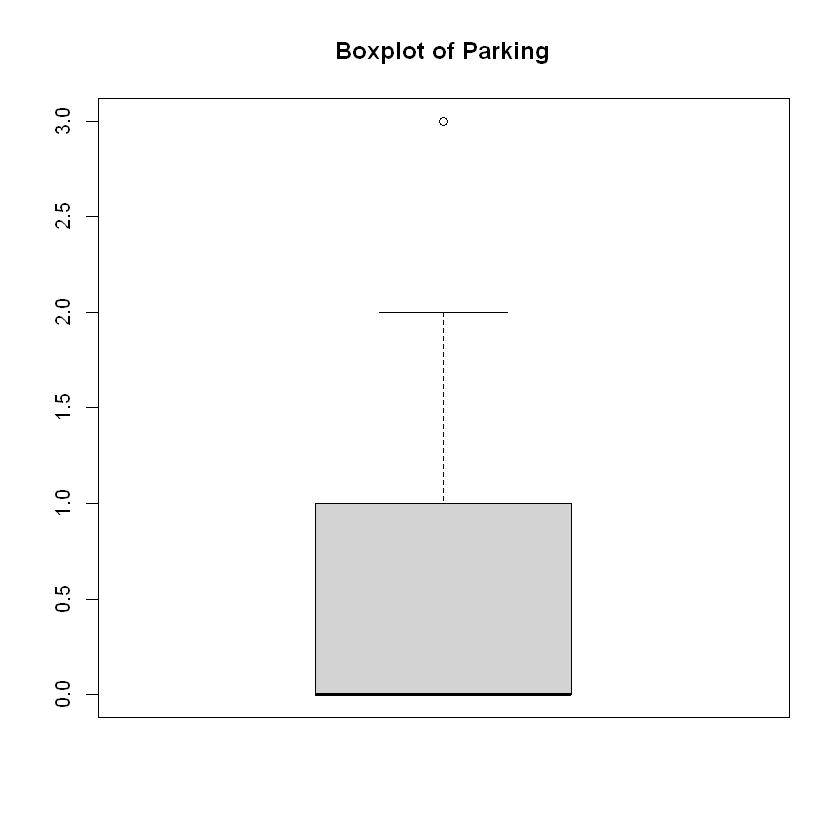

```r
# Create a boxplot to visualize and detect outliers in the 'Price' data
boxplot(data$price, main = "Boxplot of Price", outline = TRUE)
OutPrice <- boxplot.stats(data$price)$out
cat("Number of outliers for Price:", sum(data$price %in% OutPrice), "\n")

# Create a boxplot to visualize and detect outliers in the 'Area' data
boxplot(data$area, main = "Boxplot of Area", outline = TRUE)
OutArea <- boxplot.stats(data$area)$out
cat("Number of outliers for Area:", sum(data$area %in% OutArea), "\n")

# Create a boxplot to visualize and detect outliers in the 'Bedrooms' data
boxplot(data$bedrooms, main = "Boxplot of Bedrooms", outline = TRUE)
OutBedrooms <- boxplot.stats(data$bedrooms)$out
cat("Number of outliers for Bedrooms:", sum(data$bedrooms %in% OutBedrooms), "\n")

# Create a boxplot to visualize and detect outliers in the 'Bathrooms' data
boxplot(data$bathrooms, main = "Boxplot of Bathrooms", outline = TRUE)
OutBathrooms <- boxplot.stats(data$bathrooms)$out
cat("Number of outliers for Bathrooms:", sum(data$bathrooms %in% OutBathrooms), "\n")

# Create a boxplot to visualize and detect outliers in the 'Stories' data
boxplot(data$stories, main = "Boxplot of Stories", outline = TRUE)
OutStories <- boxplot.stats(data$stories)$out
cat("Number of outliers for Stories:", sum(data$stories %in% OutStories), "\n")

# Create a boxplot to visualize and detect outliers in the 'Parking' data
boxplot(data$parking, main = "Boxplot of Parking", outline = TRUE)
OutParking <- boxplot.stats(data$parking)$out
cat("Number of outliers for Parking:", sum(data$parking %in% OutParking), "\n")
```

after finding the outliers we need to remove them for a cleaner dataset,and a more efficient model:

```r
#Removing Outliers
data <- data[!(data$price %in% OutPrice), ]
data <- data[!(data$area %in% OutArea), ]
data <- data[!(data$bedrooms %in% OutBedrooms), ]
data <- data[!(data$bathrooms %in% OutBathrooms), ]
data <- data[!(data$stories %in% OutStories), ]
data <- data[!(data$parking %in% OutParking), ]

head(data)
```

A data.frame: 6 × 13

|  | price <int> | area <int> | bedrooms <int> | bathrooms <int> | stories <int> | mainroad <chr> | guestroom <chr> | basement <chr> | hotwaterheating <chr> | airconditioning <chr> | parking <int> | prefarea <chr> | furnishingstatus <chr> |
| --- | --- | --- | --- | --- | --- | --- | --- | --- | --- | --- | --- | --- | --- |
| 16 | 9100000 | 6000 | 4 | 1 | 2 | yes | no | yes | no | no | 2 | no | semi-furnished |
| 17 | 9100000 | 6600 | 4 | 2 | 2 | yes | yes | yes | no | yes | 1 | yes | unfurnished |
| 19 | 8890000 | 4600 | 3 | 2 | 2 | yes | yes | no | no | yes | 2 | no | furnished |
| 20 | 8855000 | 6420 | 3 | 2 | 2 | yes | no | no | no | yes | 1 | yes | semi-furnished |
| 21 | 8750000 | 4320 | 3 | 1 | 2 | yes | no | yes | yes | no | 2 | no | semi-furnished |
| 22 | 8680000 | 7155 | 3 | 2 | 1 | yes | yes | yes | no | yes | 2 | no | unfurnished |

```r
summary(data)
```

```
     price              area          bedrooms       bathrooms
 Min.   :1750000   Min.   : 1650   Min.   :1.000   Min.   :1.00
 1st Qu.:3342500   1st Qu.: 3490   1st Qu.:2.000   1st Qu.:1.00
 Median :4200000   Median : 4300   Median :3.000   Median :1.00
 Mean   :4373745   Mean   : 4767   Mean   :2.857   Mean   :1.22
 3rd Qu.:5222000   3rd Qu.: 6000   3rd Qu.:3.000   3rd Qu.:1.00
 Max.   :9100000   Max.   :10500   Max.   :4.000   Max.   :3.00
    stories        mainroad          guestroom           basement
 Min.   :1.000   Length:463         Length:463         Length:463
 1st Qu.:1.000   Class :character   Class :character   Class :character
 Median :2.000   Mode  :character   Mode  :character   Mode  :character
 Mean   :1.616
 3rd Qu.:2.000
 Max.   :3.000
 hotwaterheating    airconditioning       parking         prefarea
 Length:463         Length:463         Min.   :0.0000   Length:463
 Class :character   Class :character   1st Qu.:0.0000   Class :character
 Mode  :character   Mode  :character   Median :0.0000   Mode  :character
                                       Mean   :0.5875
                                       3rd Qu.:1.0000
                                       Max.   :2.0000
 furnishingstatus
 Length:463
 Class :character
 Mode  :character
```

Notice that after performing data cleaning the ranges of some attributes has changed, which should be considered since we are going to transform each attribute by encoding them into factors by relying on the range of the attribute, eg. if an attribute had a range of 1-6 but after data cleaning it ranges from 1 to 4, if we didnt know that the attribute range had changed we would encode non-existent values which may cause some issues with the code.

## 2. Data Transformation

2.1 We used Encoding to transform Categorical, and Numeric data into factors, which would help the model read the data easily, perform machine learning algorithms, and statistical analysis:

```r
data$furnishingstatus <- factor(data$furnishingstatus,
                                levels = c("furnished",
                                           "semi-furnished", "unfurnished"),
                                labels = c("3", "2", "1"))

data$mainroad <- factor(data$mainroad,
                        levels = c("no", "yes"),
                        labels = c("0", "1"))

data$guestroom <- factor(data$guestroom,
                         levels = c("no", "yes"),
                         labels = c("0", "1"))

data$hotwaterheating <- factor(data$hotwaterheating,
                               levels = c("no", "yes"),
                               labels = c("0", "1"))

data$airconditioning <- factor(data$airconditioning,
                               levels = c("no", "yes"),
                               labels = c("0", "1"))

data$prefarea <- factor(data$prefarea,
                        levels = c("no", "yes"),
                        labels = c("0", "1"))

data$basement <- factor(data$basement,
                        levels = c("no", "yes"),
                        labels = c("0", "1"))

data$bedrooms <- factor(data$bedrooms,
                        levels = c("1", "2", "3", "4"),
                        labels = c("1", "2", "3", "4"))

data$bathrooms <- factor(data$bathrooms,
                         levels = c("1", "2", "3"),
                         labels = c("1", "2", "3"))

data$stories <- factor(data$stories,
                       levels = c("1", "2", "3"),
                       labels = c("1", "2", "3"))

data$parking <- factor(data$parking,
                       levels = c("0", "1", "2"),
                       labels = c("0", "1", "2"))
```

```r
head(data)
```

A data.frame: 6 × 13

|  | price <int> | area <int> | bedrooms <fct> | bathrooms <fct> | stories <fct> | mainroad <fct> | guestroom <fct> | basement <fct> | hotwaterheating <fct> | airconditioning <fct> | parking <fct> | prefarea <fct> | furnishingstatus <fct> |
| --- | --- | --- | --- | --- | --- | --- | --- | --- | --- | --- | --- | --- | --- |
| 16 | 9100000 | 6000 | 4 | 1 | 2 | 1 | 0 | 1 | 0 | 0 | 2 | 0 | 2 |
| 17 | 9100000 | 6600 | 4 | 2 | 2 | 1 | 1 | 1 | 0 | 1 | 1 | 1 | 1 |
| 19 | 8890000 | 4600 | 3 | 2 | 2 | 1 | 1 | 0 | 0 | 1 | 2 | 0 | 3 |
| 20 | 8855000 | 6420 | 3 | 2 | 2 | 1 | 0 | 0 | 0 | 1 | 1 | 1 | 2 |
| 21 | 8750000 | 4320 | 3 | 1 | 2 | 1 | 0 | 1 | 1 | 0 | 2 | 0 | 2 |
| 22 | 8680000 | 7155 | 3 | 2 | 1 | 1 | 1 | 1 | 0 | 1 | 2 | 0 | 1 |

2.2 we used the Discretization technique on our class label "price" to simplify and clear the interpretation of the large continuous values by making them fall into intervals, making it easier to analyze and communicate the result of the model eventually, we used histogram to show us a clear view of the value distribution for our class label: price, and discretized it into two categories (low, high), low meaning it is less than the median of the price, and high meaning it is equal to or higher than the median. We did it using the method quantile(), and we identified the break points for the attribute, then we discretized it using the method cut() with the breakpoints that we identified using quantile(), and we specified the labels which are again (high, and low).

the code is as shown:

```r
# Calculate quantiles for 'data$price'
breaks_price <- quantile(data$price, probs = c(0, 0.5, 1), na.rm = TRUE)
data$price <- cut(data$price, breaks = breaks_price, include.lowest = TRUE, labels = c("Low","High"))
```

```r
head(data)
```

A data.frame: 6 × 13

|  | price <fct> | area <int> | bedrooms <fct> | bathrooms <fct> | stories <fct> | mainroad <fct> | guestroom <fct> | basement <fct> | hotwaterheating <fct> | airconditioning <fct> | parking <fct> | prefarea <fct> | furnishingstatus <fct> |
| --- | --- | --- | --- | --- | --- | --- | --- | --- | --- | --- | --- | --- | --- |
| 16 | High | 6000 | 4 | 1 | 2 | 1 | 0 | 1 | 0 | 0 | 2 | 0 | 2 |
| 17 | High | 6600 | 4 | 2 | 2 | 1 | 1 | 1 | 0 | 1 | 1 | 1 | 1 |
| 19 | High | 4600 | 3 | 2 | 2 | 1 | 1 | 0 | 0 | 1 | 2 | 0 | 3 |
| 20 | High | 6420 | 3 | 2 | 2 | 1 | 0 | 0 | 0 | 1 | 1 | 1 | 2 |
| 21 | High | 4320 | 3 | 1 | 2 | 1 | 0 | 1 | 1 | 0 | 2 | 0 | 2 |
| 22 | High | 7155 | 3 | 2 | 1 | 1 | 1 | 1 | 0 | 1 | 2 | 0 | 1 |

### This step is to keep data before dropping the class label (In clustering).

```r
### load the data after preprocessing to a CSV file
write.csv(data, file = "Dataset/HousingEncoded.csv")
```

# 3. Feature selection

Feature selection is a process of selecting a subset of relevant features (or attributes) from the original set of features in a dataset. The goal of feature selection is to choose the most relevant and important features, thereby reducing dimensionality, and improving model performance.

we used a random forest model with the cross-validation method to try different size of subsets of predictors(attributes other than the class label), and compute the accuracy of each subset size to see which subset size provides the highest accuracy for our model:

```
Recursive feature selection

Outer resampling method: Cross-Validated (10 fold)

Resampling performance over subset size:

 Variables Accuracy  Kappa AccuracySD KappaSD Selected
         1   0.6695 0.3345    0.07158 0.14268
         2   0.7043 0.3986    0.06483 0.12793
         3   0.7024 0.3946    0.06942 0.13932
         4   0.7238 0.4386    0.06324 0.12925
         5   0.7391 0.4706    0.04725 0.09495
         6   0.7500 0.4946    0.05947 0.11917
         7   0.7694 0.5348    0.05682 0.11479
         8   0.7565 0.5086    0.06259 0.12650
         9   0.7607 0.5173    0.05533 0.11163
        10   0.7675 0.5313    0.07241 0.14674
        11   0.7781 0.5530    0.05676 0.11532
        12   0.7804 0.5575    0.06147 0.12416        *

The top 5 variables (out of 12):
   area, prefarea, mainroad, guestroom, furnishingstatus
```

1. 'area'

2. 'prefarea'

3. 'mainroad'

4. 'guestroom'

5. 'furnishingstatus'

6. 'bedrooms'

7. 'airconditioning'

8. 'basement'

9. 'bathrooms'

10. 'stories'

11. 'parking'

12. 'hotwaterheating'

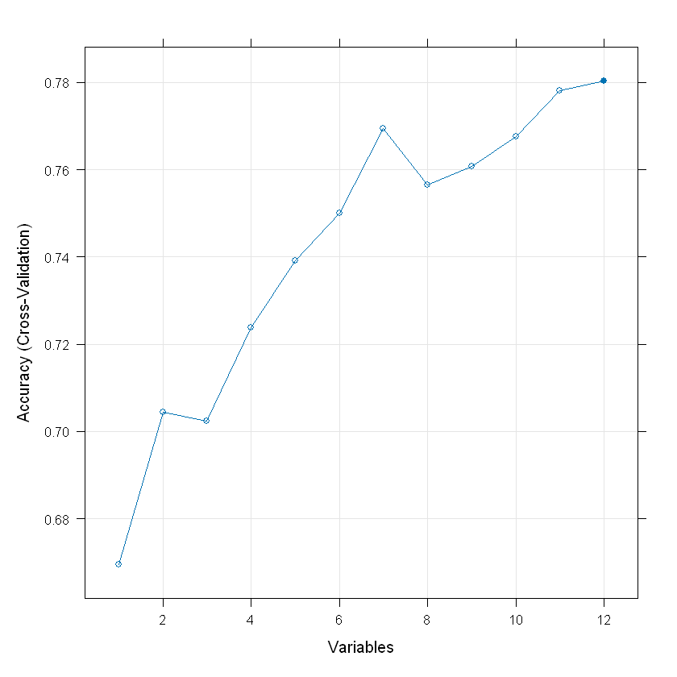

```r
#Feature Selection

#ensure the results are repeatable
set.seed(7)
# load the library
library(caret)

# define the control using a random forest selection function
control <- rfeControl(functions=rfFuncs, method="cv", number=10)

# run the RFE algorithm
results <- rfe(data[,-1], data[,1], sizes=c(1:12), rfeControl=control)
# summarize the results
print(results)
# list the chosen features
predictors(results)
# plot the results
plot(results, type=c("g", "o"))
```

We used the RFE algorithm which uses cross-validation with 10 folds to assess the performance of different feature subsets. The table shows how the accuracy and Kappa (a measure of agreement beyond chance) change as the number of selected features increases. It also provides the standard deviations for accuracy and Kappa, also the graph shows a clear sight over the accuracy changing whenever we try a new subset of features.

- Initially, with only 1 feature selected, the model achieved an accuracy of 66.95%. As more features are added, the accuracy values generally improve. The model's performance continues to improve as more features are included, and it reaches its peak performance when 12 features are selected, with an accuracy of 78.04% These features are marked with an asterisk (*) under the "Selected" column.

The top 5 variables (out of the 12 **SELECTED** features) are: 'area,' 'prefarea' (whether the house is in a preferred area), 'mainroad' (whether it's on the main road), 'guestroom' (whether it has a guest room), and 'furnishingstatus' (the furnishing status of the house). These features are considered the most important in predicting the 'price' of houses but it is better for the model predictivity to use all 12 features because it has the highest accuracy out of all the other number of features selected.

# **Data Mining Task**

We employed both supervised and unsupervised learning techniques on our dataset (housing prices), which involves classification and clustering methods, as for classification we did a partitioning method called the train-test split, which splits the dataset into two subsets of different ratios, and we implemented three algorithms to form 9 different decision trees.

# **1. Classification:**

Classification is the task of assigning labels to data based on its features which is a supervised learning technique. To assess a classification model's performance, we use a train-test split, dividing the data into a training set for model building and a testing set for evaluation. We perform multiple splits, such as 70-30, 80-20, and 90-10, to check the model's consistency and robustness across different data subsets. This approach ensures reliable and generalizable model evaluations and use the information gain(ID3), Gain ratio(C5.0), and Gini index (CART) algorithms on all of the 3 splits.

### **Dividing the dataset:**

we used the rsample package because it uses the sampling technique without replacement which can be more biased if it was with replacement.

we divided our dataset into two divisions for each split:

dividing the data set:

```r
install.packages("rsample")
library(rsample)
#make this example reproducible
set.seed(1)

#use 70% of dataset as training set and 30% as test set
sample1 <- initial_split(data, prop=0.70)
trainData1  <- training(sample1)
testData1 <- testing(sample1)

#use 80% of dataset as training set and 20% as test set
sample2 <- initial_split(data, prop=0.80)
trainData2  <- training(sample2)
testData2 <- testing(sample2)

#use 90% of dataset as training set and 10% as test set
sample3 <- initial_split(data, prop=0.90)
trainData3  <- training(sample3)
testData3 <- testing(sample3)
```

### **1.1 Bulding the tree using Gain Ratio(C5.0).**

C5.0 is a common algorithm for building decision trees, and the gain ratio is used in the construction of these trees. Gain ratio is a measure that helps to select the best splitting attribute at each node of the decision tree.

When constructing a decision tree, the algorithm considers different attributes or features at each node and chooses the one that maximizes the gain ratio. Gain ratio can be calculated by taking into account the information gain and the intrinsic information of the attribute.

**Note**:

- **Information Gain (IG):** A measure of the effectiveness of an attribute in classifying the data. It is calculated by comparing the entropy of the dataset before and after the split based on an attribute. Entropy is a measure of impurity or disorder in a set of data.
- **Intrinsic Information (II):** This is a measure of the amount of uncertainty in a set of data.

**Explanation of the code:**

we loaded the library of C5.0 and some other libraries for printing the results, built a model using the c5.0 method which uses the C5.0 to construct the model on the selected trainData and we specified 'price~.' which means it would predict the price variable based on all the rest of the attributes.

By using the predict() method we are using the trained model we have built to make predictions on our testData, the type="class" specifies that we want to get class labels as the predictions.

then we evaluated the model by constructing a cofusion matrix using the predicted data and comparing it to the actual class labels of this data. and lastly, we used the plot() method to visualize our decision trees and how they had made decisions, we did that on all of the three splits we have created on step 1.

**A. C5.0 with 70-30 split:**

```
Confusion Matrix and Statistics

          Reference
Prediction Low High
      Low   61   22
      High  11   45

               Accuracy : 0.7626
                 95% CI : (0.6831, 0.8306)
    No Information Rate : 0.518
    P-Value [Acc > NIR] : 2.598e-09

                  Kappa : 0.5218

 Mcnemar's Test P-Value : 0.08172

            Sensitivity : 0.8472
            Specificity : 0.6716
         Pos Pred Value : 0.7349
         Neg Pred Value : 0.8036
             Prevalence : 0.5180
         Detection Rate : 0.4388
   Detection Prevalence : 0.5971
      Balanced Accuracy : 0.7594

       'Positive' Class : Low
```

[figure not shown]

```r
library(C50)
library(printr)
library(caret)

model <- C5.0(price ~., data=trainData1)
results <- predict(object=model, newdata=testData1, type="class")

conf_matrix <- confusionMatrix(results, testData1$price)
print(conf_matrix)

plot(model)
```

## **Outcome Analysis:**

### **2. Performance:**

- **Accuracy:** 76.26%  
  The proportion of correctly classified instances.
- **Sensitivity (True Positive Rate):** 84.72%  
  The proportion of actual positives correctly predicted.
- **Specificity (True Negative Rate):** 67.16%  
  The proportion of actual negatives correctly predicted.
- **Positive Predictive Value (Precision):** 73.49%  
  The proportion of predicted positives correctly predicted.
- **Negative Predictive Value:** 80.36%  
  The proportion of predicted negatives correctly predicted.

This revised analysis aligns with the information provided in the confusion matrix, ensuring consistency between the performance metrics and the actual counts of true positives, true negatives, false positives, and false negatives.

### **3. Plot Analysis:**

**B. C5.0 with 80-20 split:**

```
Confusion Matrix and Statistics

          Reference
Prediction Low High
      Low   36   12
      High   9   36

               Accuracy : 0.7742
                 95% CI : (0.6758, 0.8545)
    No Information Rate : 0.5161
    P-Value [Acc > NIR] : 2.632e-07

                  Kappa : 0.5489

 Mcnemar's Test P-Value : 0.6625

            Sensitivity : 0.8000
            Specificity : 0.7500
         Pos Pred Value : 0.7500
         Neg Pred Value : 0.8000
             Prevalence : 0.4839
         Detection Rate : 0.3871
   Detection Prevalence : 0.5161
      Balanced Accuracy : 0.7750

       'Positive' Class : Low
```

[figure not shown]

```r
model <- C5.0(price ~., data=trainData2)
results <- predict(object=model, newdata=testData2, type="class")

conf_matrix <- confusionMatrix(results, testData2$price)
print(conf_matrix)

plot(model)
```

## **Outcome Analysis**

### **2. Performance:**

- **Accuracy:** 77.42%  
  The proportion of correctly classified instances.
- **Sensitivity (True Positive Rate):** 80.00%  
  The proportion of actual positives correctly predicted.
- **Specificity (True Negative Rate):** 75.00%  
  The proportion of actual negatives correctly predicted.
- **Positive Predictive Value (Precision):** 75.00%  
  The proportion of predicted positives correctly predicted.
- **Negative Predictive Value:** 80.00%  
  The proportion of predicted negatives correctly predicted.

The model shows a slightly improved accuracy compared to the previous one(the one performed on 70-30 split) (accuracy was 76.26% while this one is 77.42%). Sensitivity and specificity are both high and more balanced than the previous decision tree. Compared to the previous model, this model has better performance since its accuracy, and specificity are higher than the previous one, but the previous one has higher sensitivity, indicating better performance in correctly identifying the positive class, but since its no big of a difference we may choose this as a better model than the previous one.

### **3. Plot Analysis:**

**C. C5.0 with 90-10 split:**

```
Confusion Matrix and Statistics

          Reference
Prediction Low High
      Low   22    6
      High   9   10

               Accuracy : 0.6809
                 95% CI : (0.5288, 0.8091)
    No Information Rate : 0.6596
    P-Value [Acc > NIR] : 0.4453

                  Kappa : 0.3202

 Mcnemar's Test P-Value : 0.6056

            Sensitivity : 0.7097
            Specificity : 0.6250
         Pos Pred Value : 0.7857
         Neg Pred Value : 0.5263
             Prevalence : 0.6596
         Detection Rate : 0.4681
   Detection Prevalence : 0.5957
      Balanced Accuracy : 0.6673

       'Positive' Class : Low
```

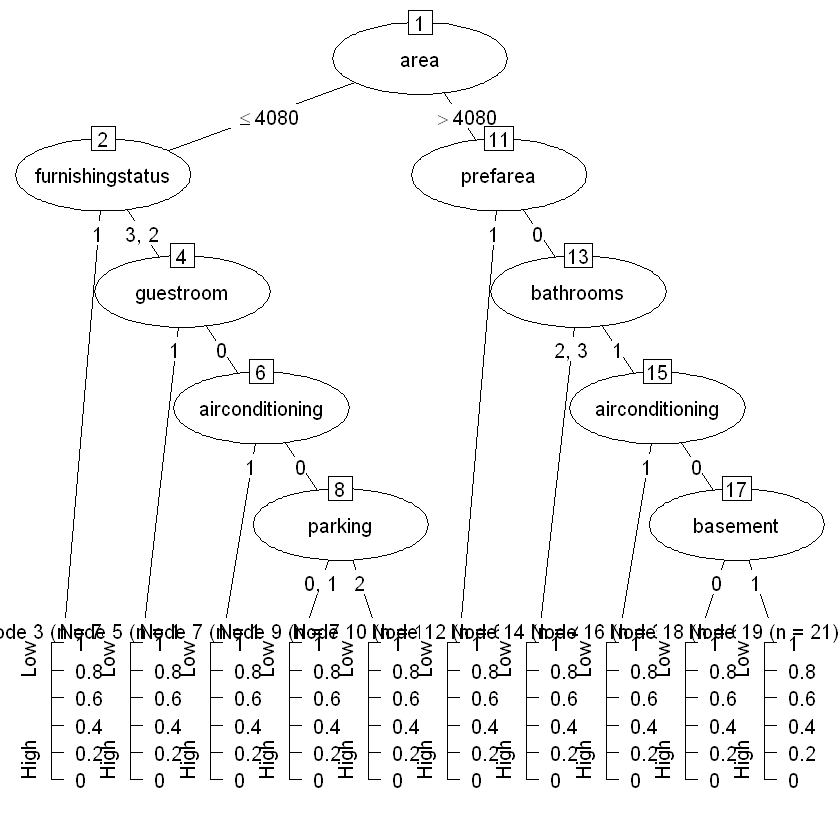

```r
model <- C5.0(price ~., data=trainData3)
results <- predict(object=model, newdata=testData3, type="class")

conf_matrix <- confusionMatrix(results, testData3$price)
print(conf_matrix)

plot(model)
```

## **Outcome Analysis:**

### **2. Performance:**

- **Accuracy:** 68.09%  
  The proportion of correctly classified instances.
- **Sensitivity (True Positive Rate):** 70.97%  
  The proportion of actual positives correctly predicted.
- **Specificity (True Negative Rate):** 62.50%  
  The proportion of actual negatives correctly predicted.
- **Positive Predictive Value (Precision):** 78.57%  
  The proportion of predicted positives correctly predicted.
- **Negative Predictive Value:** 52.63%  
  The proportion of predicted negatives correctly predicted.

### **3. Plot Analysis:**

- it is clear that the first splitting attribute was area and if the house has 4080 square feet of area or less and have a furnishingstatus of 1(unfurnished) would have a low price but if the furnishing status is either furnished or semi-furnished (2 or 3) and the house has a guestroom then the price would most likely be high.
- However, if it was under the same criteria but it had no guestroom, no airconditioning and 1 or no parking it would most likely be low.
- plus, if it was on the same criteria and it had 2 parkings it would give the same result as the previous node, most likely a low price.
- if the area was larger than 4080 square feet and the house was on a preferred area then the price is almost definitely high.
- but if it wasnt on a preferred area and it had 2,3 bathrooms it would be most likely high as well but less of a probability than the previous one.
- if it had only one bathroom and is still on the same criteria and it had no airconditioning and no basement it would probably be a lower price.
- if it did have airconditioning it would most likely be on the higher prices.

### **1.2 Building the Tree using Gini Index(CART).**

In classification using decision trees, the Gini index is a measure of impurity in a node. It evaluates how often a randomly chosen element would be incorrectly classified. The goal is to minimize the Gini index by making splits that result in more homogenous subsets. A lower Gini index indicates a more pure node, contributing to trying to find an accurate decision tree for classification.

Nodes with a Gini index close to 0 are considered pure, meaning most instances in the node belong to the same class.

**Explanation of the code:**

- Firstly, we load the rpart package for the CART algorithm and the rpart.plot for visualizing the decision tree we are going to create.
- using rpart() method we identifiead a variable 'fit.tree' which will contain our constructed model by applying CART algorithm on our trainData, setting method="class" to indicate that this is a classification task, and 'cp = 0.008' to set the complexity parameter, which is what controls the level of tree complexity and would help avoid overfitting, ad then printng the fit.tree which prints some details about the decision tree model.
- using rpart.plot() to see how our decision tree looks with the amazing visualization from the rpart package.
- checking variable importance for each attribute in the dataset to check which feature has the most impact on our predictions and order them accordingly.
- predicting the class labels using the trained model 'fit.tree' o the testData.
- and Lastly, creating a confusion matrix to compare the predictions with the actual class labels.

**A. CART on the 70-30 split:**

```
n= 324

node), split, n, loss, yval, (yprob)
      * denotes terminal node

 1) root 324 149 Low (0.54012346 0.45987654)
   2) area< 4505 180  45 Low (0.75000000 0.25000000)
     4) furnishingstatus=1 68   5 Low (0.92647059 0.07352941) *
     5) furnishingstatus=3,2 112  40 Low (0.64285714 0.35714286)
      10) guestroom=0 103  32 Low (0.68932039 0.31067961)
        20) area< 3645 63  12 Low (0.80952381 0.19047619) *
        21) area>=3645 40  20 Low (0.50000000 0.50000000)
          42) parking=0 22   7 Low (0.68181818 0.31818182) *
          43) parking=1,2 18   5 High (0.27777778 0.72222222) *
      11) guestroom=1 9   1 High (0.11111111 0.88888889) *
   3) area>=4505 144  40 High (0.27777778 0.72222222)
     6) bathrooms=1 104  40 High (0.38461538 0.61538462)
      12) prefarea=0 72  34 Low (0.52777778 0.47222222)
        24) airconditioning=0 46  16 Low (0.65217391 0.34782609)
          48) furnishingstatus=3,1 23   4 Low (0.82608696 0.17391304) *
          49) furnishingstatus=2 23  11 High (0.47826087 0.52173913)
            98) area< 6040 16   7 Low (0.56250000 0.43750000) *
            99) area>=6040 7   2 High (0.28571429 0.71428571) *
        25) airconditioning=1 26   8 High (0.30769231 0.69230769) *
      13) prefarea=1 32   2 High (0.06250000 0.93750000) *
     7) bathrooms=2,3 40   0 High (0.00000000 1.00000000) *
```

**area**

43.0017765012872

**prefarea**

16.5294660757624

**airconditioning**

12.8621536809943

**guestroom**

11.7805371147216

**furnishingstatus**

9.74096217682683

**parking**

9.15207679438172

**bathrooms**

9.08572908572909

**stories**

3.94001807298141

**bedrooms**

1.27423133472283

**basement**

0.964061959651122

**mainroad**

0.362948960302457

```
pred.tree Low High
     Low   59   20
     High  13   47
```

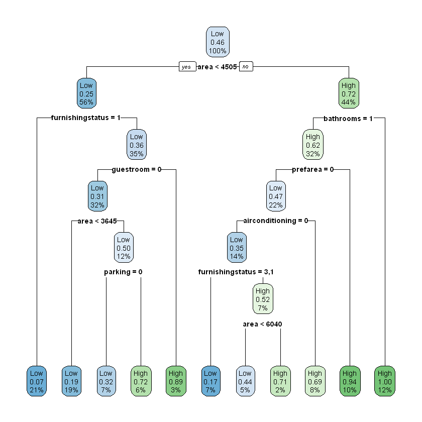

```r
# For decision tree model
install.packages("rpart")
library(rpart)
# For data visualization
library(rpart.plot)


fit.tree = rpart(price ~ ., data=trainData1, method = "class", cp=0.008)
fit.tree

# Visualizing the unpruned tree
rpart.plot(fit.tree)

# Checking the order of variable importance
fit.tree$variable.importance

pred.tree = predict(fit.tree, testData1, type = "class")

table(pred.tree,testData1$price)
```

The tree starts with the root node (1) and branches based on various conditions until terminal nodes marked with "*". Each node provides information such as the number of observations (n), the number of misclassifications (loss), the predicted value (yval), and the class probabilities (yprob).

#### **Model A Outcome Analysis**

##### **1. Overall Performance**

in the root node:

- The entire dataset consists of 324 observations.
- The majority class "Low" comprises approximately 54.01%, while the minority class "High" comprises about 45.98% of the dataset.

##### **2. Splitting Criteria**

- The tree branches based on conditions like 'area', 'furnishingstatus', 'guestroom', 'bathrooms', 'prefarea', 'airconditioning', and 'parking'.
- For example, the tree splits at 'area < 4505' into subsets where 'furnishingstatus = 1' or 'furnishingstatus = 2 or 3'.

##### **3. Terminal Nodes**

- Terminal nodes represent final decision outcomes based on specific conditions.
- Node 4 indicates that if 'area' is < 4505 and 'furnishingstatus' is 1, the prediction is "Low" with a high probability (92.64%).

##### **4. Model Accuracy**

The accuracy of the model can be assessed by looking at the confusion matrix generated by predictions on the test set. Further analysis metrics such as precision, and recall can provide a more detailed evaluation of the model's performance:

**Accuracy:**

- Accuracy = (TP + TN) / (TP + TN + FP + FN)
- Accuracy = (47 + 59) / (47 + 59 + 20 + 13) = 106 / 139 ≈ 0.7626 or 76.26%

**Misclassification Rate:**

- Misclassification Rate = (FP + FN) / (TP + TN + FP + FN)
- Misclassification Rate = (20 + 13) / (47 + 59 + 20 + 13) = 33 / 139 ≈ 0.2374 or 23.74%
- The model in this case shows a reasonably good accuracy of approximately 76.26%. Precision and recall are relatively balanced. The misclassification rate is low, suggesting some room for improvement.

##### **5. Visualizing the Tree**

The visualization of the unpruned tree provides a graphical representation of the decision-making process. It can be helpful in understanding the flow of the decision tree and identifying key decision points.

eg. 12% of the training dataset have 100% high prices and they satisfy those conditions:

1. area > 4505
2. bathrooms are higher than 1

**B. CART on the 80-20 split:**

```
n= 370

node), split, n, loss, yval, (yprob)
      * denotes terminal node

  1) root 370 168 Low (0.54594595 0.45405405)
    2) area< 4505 209  52 Low (0.75119617 0.24880383)
      4) furnishingstatus=1 84   5 Low (0.94047619 0.05952381) *
      5) furnishingstatus=3,2 125  47 Low (0.62400000 0.37600000)
       10) parking=0 80  22 Low (0.72500000 0.27500000)
         20) guestroom=0 72  16 Low (0.77777778 0.22222222) *
         21) guestroom=1 8   2 High (0.25000000 0.75000000) *
       11) parking=1,2 45  20 High (0.44444444 0.55555556)
         22) bedrooms=2 15   3 Low (0.80000000 0.20000000) *
         23) bedrooms=3,4 30   8 High (0.26666667 0.73333333) *
    3) area>=4505 161  45 High (0.27950311 0.72049689)
      6) prefarea=0 108  44 High (0.40740741 0.59259259)
       12) bathrooms=1 82  40 Low (0.51219512 0.48780488)
         24) airconditioning=0 56  21 Low (0.62500000 0.37500000)
           48) area< 6210 35   8 Low (0.77142857 0.22857143)
             96) furnishingstatus=3,1 15   0 Low (1.00000000 0.00000000) *
             97) furnishingstatus=2 20   8 Low (0.60000000 0.40000000)
              194) area>=5450 9   1 Low (0.88888889 0.11111111) *
              195) area< 5450 11   4 High (0.36363636 0.63636364) *
           49) area>=6210 21   8 High (0.38095238 0.61904762) *
         25) airconditioning=1 26   7 High (0.26923077 0.73076923) *
       13) bathrooms=2,3 26   2 High (0.07692308 0.92307692) *
      7) prefarea=1 53   1 High (0.01886792 0.98113208) *
```

**area**

48.8767944807304

**prefarea**

17.5209871824664

**furnishingstatus**

13.3605547720362

**airconditioning**

12.2869534336457

**guestroom**

11.0491485766881

**bathrooms**

9.99381550887752

**parking**

9.41827350270994

**bedrooms**

6.96504088504089

**stories**

4.27217269243335

**basement**

0.688870496609386

**hotwaterheating**

0.605731088664422

```
pred.tree Low High
     Low   32    9
     High  13   39
```

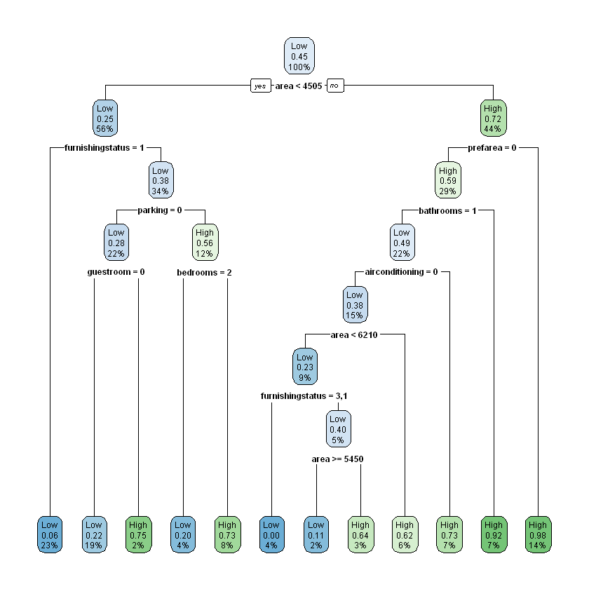

```r
# For decision tree model
install.packages("rpart")
library(rpart)
# For data visualization
library(rpart.plot)

# Get the list of data sets contained in package
fit.tree = rpart(price ~ ., data=trainData2, method = "class", cp=0.008)
fit.tree

# Visualizing the unpruned tree
rpart.plot(fit.tree)

# Checking the order of variable importance
fit.tree$variable.importance

pred.tree = predict(fit.tree, testData2, type = "class")

table(pred.tree,testData2$price)
```

#### **Model B Outcome Analysis:**

##### **1. Performance:**

The root node signifies the entire training dataset (n = 370). The majority class is "Low" with a probability of 54.59%, while the minority class is "High" with a probability of 45.41%.

Upon splitting by 'area', the dataset divides into 209 instances, indicating 52 misclassifications as 'Low'. 75.15% are classified as the positive class ('Low'), while 24.88% as the negative class ('High'). Node 4, a terminal node, implies conditions where the area is less than 4505, and furnishing status is 1, leading to a 94% probability of being 'Low' with 5 misclassified values.

Comparison with Model A showcases similar performance characteristics, with both models having the majority class as "Low" and the minority class as "High". However, slight differences exist in the probabilities associated with these classes, making this model marginally more accurate.

##### **2. Splitting Criteria:**

The tree branches based on diverse conditions like 'area', 'furnishingstatus', 'bedrooms', 'parking', etc. These conditions facilitate better data partitioning for precise predictions, e.g., 'parking = 1,2'.

##### **3. Terminal Nodes:**

Comparison with Model A demonstrates similar terminal nodes where 'furnishingstatus' being 1 results in a high probability prediction of "Low."

Both models seem to follow a comparable decision-making process, though with differing splits and conditions at each node. Critical conditions like 'area,' 'furnishingstatus,' and 'prefarea' play vital roles in determining final predictions.

##### **4. Model Accuracy:**

The accuracy of the model can be assessed by looking at the confusion matrix generated by predictions on the test set. Further analysis metrics such as precision, and recall can provide a more detailed evaluation of the model's performance.

**Accuracy:**

- Accuracy = (TP + TN) / (TP + TN + FP + FN)
- Accuracy = (32 + 39) / (32 + 39 + 9 + 13) ≈ 0.7634 or 76.34%

**Precision (Positive Predictive Value):**

- Precision = TP / (TP + FP)
- Precision = 32 / (32 + 9) ≈ 0.7804 or 78.04%

**Recall (Sensitivity or True Positive Rate):**

- Recall = TP / (TP + FN)
- Recall = 32 / (32 + 13) ≈ 0.7111 or 71.11%

**Specificity (True Negative Rate):**

- Specificity = TN / (TN + FP)
- Specificity = 39 / (39 + 9) ≈ 0.8125 or 81.25%

**Misclassification Rate:**

- Misclassification Rate = (FP + FN) / (TP + TN + FP + FN)
- Misclassification Rate = (9 + 13) / (32 + 39 + 9 + 13) = 0.2366 or 23.66%

**Conclusion**

- The model shows reasonably good performance with an accuracy of approximately 76.34% which shows a slightly higher accuracy compared to Model A (the previous model) which was 76.26%. It correctly identifies both "Low" and "High" classes, as indicated by the balanced values of precision and recall resembling the balanced values of model A. The misclassification rate is relatively low, and lower than the previous model slightly. Overall, this model resembles the previous model extremely but this one exceeeds it by few points only.

##### **5. Visualizing the Tree:**

The visualization of the unpruned tree provides a graphical representation of the decision-making process. It can be helpful in understanding the flow of the decision tree and identifying key decision points.

eg. the class label is 98% a 'High' price when it satisfies those conditions:

**C. CART on the 90-10 split:**

```
n= 416

node), split, n, loss, yval, (yprob)
      * denotes terminal node

 1) root 416 200 Low (0.51923077 0.48076923)
   2) area< 4087.5 188  43 Low (0.77127660 0.22872340)
     4) furnishingstatus=1 74   3 Low (0.95945946 0.04054054) *
     5) furnishingstatus=3,2 114  40 Low (0.64912281 0.35087719)
      10) guestroom=0 104  32 Low (0.69230769 0.30769231)
        20) bedrooms=1,2 29   2 Low (0.93103448 0.06896552) *
        21) bedrooms=3,4 75  30 Low (0.60000000 0.40000000)
          42) parking=0 49  13 Low (0.73469388 0.26530612) *
          43) parking=1,2 26   9 High (0.34615385 0.65384615) *
      11) guestroom=1 10   2 High (0.20000000 0.80000000) *
   3) area>=4087.5 228  71 High (0.31140351 0.68859649)
     6) prefarea=0 163  70 High (0.42944785 0.57055215)
      12) bathrooms=1 122  57 Low (0.53278689 0.46721311)
        24) airconditioning=0 83  29 Low (0.65060241 0.34939759)
          48) basement=0 62  16 Low (0.74193548 0.25806452) *
          49) basement=1 21   8 High (0.38095238 0.61904762)
            98) area>=5252.5 10   4 Low (0.60000000 0.40000000) *
            99) area< 5252.5 11   2 High (0.18181818 0.81818182) *
        25) airconditioning=1 39  11 High (0.28205128 0.71794872) *
      13) bathrooms=2,3 41   5 High (0.12195122 0.87804878) *
     7) prefarea=1 65   1 High (0.01538462 0.98461538) *
```

**area**

47.0531393004093

**prefarea**

15.9341703716583

**airconditioning**

11.6124388714318

**furnishingstatus**

10.4005219498598

**bathrooms**

10.3591078905861

**parking**

9.76509210634474

**bedrooms**

9.12268862577659

**mainroad**

6.72272735325795

**guestroom**

6.16276138183019

**basement**

4.08824237040327

**stories**

3.08226499172242

**hotwaterheating**

0.59177635551262

```
pred.tree Low High
     Low   25    5
     High   6   11
```

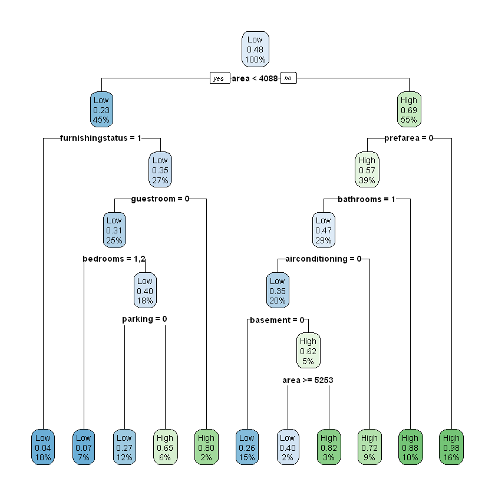

```r
# For decision tree model
install.packages("rpart")
library(rpart)
# For data visualization
library(rpart.plot)

# Get the list of data sets contained in package
fit.tree = rpart(price ~ ., data=trainData3, method = "class", cp=0.008)
fit.tree

# Visualizing the unpruned tree
rpart.plot(fit.tree)

# Checking the order of variable importance
fit.tree$variable.importance

pred.tree = predict(fit.tree, testData3, type = "class")

table(pred.tree,testData3$price)
```

#### **Model C Outcome Analysis:**

##### **1. Performance:**

In the entire training dataset (n = 416), the root node shows the majority class as "Low" with a probability of approximately 51.92%, while the minority class is "High" with a probability of around 48.08%.

Splitting by 'area', for n = 188 with 43 misclassified values as "Low," 77% are classified as the positive class ('Low'), and 23% as the negative class ('High'). Node 4 indicates that if the area is less than 4087.5 and furnishing status is 1, there is a 95.95% probability of being 'Low' with 3 misclassified values.

Comparing Model C with Models A and B, Model C shows higher accuracy than Model A and Model B.

##### **3. Terminal Nodes:**

Terminal nodes depict final decision outcomes (class labels). Node 7, for instance, indicates that if 'area' is higher than 4087.5 and 'prefarea' is 1, the prediction is "High" with a high probability of 98.46%.

Comparing Model C with Models A and B, all models indicate final decision outcomes at terminal nodes. For example, if 'furnishingstatus' is 1, the prediction across all models is "Low" with a high probability.

##### **4. Model Accuracy:**

The accuracy of the model can be assessed by looking at the confusion matrix generated by predictions on the test set. Further analysis metrics such as precision, and recall can provide a more detailed evaluation of the model's performance.

- **True Positive (TP):** 25 instances correctly predicted as "Low" class.
- **True Negative (TN):** 11 instances correctly predicted as "High" class.
- **False Positive (FP):** 5 instances incorrectly predicted as "Low" class.
- **False Negative (FN):** 6 instances incorrectly predicted as "High" class.

**Accuracy:**

- Accuracy = (TP + TN) / (TP + TN + FP + FN)
- Accuracy = (25 + 11) / (25 + 11 + 5 + 6) ≈ 0.7659 or 76.59%

**Precision (Positive Predictive Value):**

- Precision = TP / (TP + FP)
- Precision = 25 / (25 + 5) ≈ 0.8333 or 83.33%

**Recall (Sensitivity or True Positive Rate):**

- Recall = TP / (TP + FN)
- Recall = 25 / (25 + 6) = 0.8064 or 80.64%

**Specificity (True Negative Rate):**

- Specificity = TN / (TN + FP)
- Specificity = 11 / (11 + 5) ≈ 0.6875 or 68.75%

**Misclassification Rate:**

- Misclassification Rate = (FP + FN) / (TP + TN + FP + FN)
- Misclassification Rate = (5 + 6) / (25 + 11 + 5 + 6) ≈ 0.2340 or 23.40%

##### **5. Visualizing the Tree:**

The visualization of the unpruned tree provides a graphical representation of the decision-making process. It can be helpful in understanding the flow of the decision tree and identifying key decision points.

E.g., the class label is 72% a 'High' price when it satisfies those conditions:

1. Area is higher than 4088
2. not in a prefferred area
3. 1 bathroom
4. airconditioning provided

### **1.3 Building the Tree using Information Gain(ID3 Algorithm):**

Information Gain is a crucial concept in decision tree algorithms, notably the Iterative Dichotomiser 3 (ID3). ID3 uses Information Gain to choose the most informative attributes for efficient data partitioning (as splitting attributes).

Information Gain measures the reduction in uncertainty achieved by splitting data with a specific attribute, helping ID3 identify the most relevant features. The algorithm builds a decision tree by iteratively selecting attributes that maximize Information Gain, creating decision nodes that effectively classify instances.

ID3's top-down approach, guided by Information Gain, results in interpretable and accurate decision trees. This synergy makes ID3 a foundational algorithm in machine learning for classification tasks.

- as shown below, we first need to discretize the area attribute to create an effecient model, and since our model's functions are written manually and not pre-defined, it would be easier to predefine a new categorical attribute to construct the models accordingly and for the predictions to be more readable, after doscretizing the attribute we need to re-define the three splits (70-30, 80-20, 90-10) because we have added a new column to the dataset.

```r
# Define break points
breaks <- c(-Inf, 4500, Inf)

# Create a new categorical variable based on the intervals
data$area_category <- cut(data$area, breaks = breaks, labels = c("<= 4500", "> 4500"))

# Check the result
head(data)

#make this example reproducible
set.seed(1)

#use 70% of dataset as training set and 30% as test set
sample1 <- initial_split(data, prop=0.70)
trainData1  <- training(sample1)
testData1 <- testing(sample1)

#use 80% of dataset as training set and 20% as test set
sample2 <- initial_split(data, prop=0.80)
trainData2  <- training(sample2)
testData2 <- testing(sample2)

#use 90% of dataset as training set and 10% as test set
sample3 <- initial_split(data, prop=0.90)
trainData3  <- training(sample3)
testData3 <- testing(sample3)
```

A data.frame: 6 × 14

|  | price <fct> | area <int> | bedrooms <fct> | bathrooms <fct> | stories <fct> | mainroad <fct> | guestroom <fct> | basement <fct> | hotwaterheating <fct> | airconditioning <fct> | parking <fct> | prefarea <fct> | furnishingstatus <fct> | area_category <fct> |
| --- | --- | --- | --- | --- | --- | --- | --- | --- | --- | --- | --- | --- | --- | --- |
| 16 | High | 6000 | 4 | 1 | 2 | 1 | 0 | 1 | 0 | 0 | 2 | 0 | 2 | > 4500 |
| 17 | High | 6600 | 4 | 2 | 2 | 1 | 1 | 1 | 0 | 1 | 1 | 1 | 1 | > 4500 |
| 19 | High | 4600 | 3 | 2 | 2 | 1 | 1 | 0 | 0 | 1 | 2 | 0 | 3 | > 4500 |
| 20 | High | 6420 | 3 | 2 | 2 | 1 | 0 | 0 | 0 | 1 | 1 | 1 | 2 | > 4500 |
| 21 | High | 4320 | 3 | 1 | 2 | 1 | 0 | 1 | 1 | 0 | 2 | 0 | 2 | <= 4500 |
| 22 | High | 7155 | 3 | 2 | 1 | 1 | 1 | 1 | 0 | 1 | 2 | 0 | 1 | > 4500 |

#### **Explanation of the code:**

This R code implements the ID3 (Iterative Dichotomiser 3) algorithm for constructing decision trees. The code consists of several functions:

##### 1. **Entropy Calculation:**

- The `calculate_entropy` function computes the entropy of a set of class probabilities. The formula for entropy is applied to each class probability, and the result is summed up with negation.

##### 2. **Information Gain Calculation:**

- The `calculate_information_gain` function computes the information gain for a given attribute in the dataset. It involves calculating the entropy of the entire dataset and the weighted sum of entropies for each partition formed by the attribute values.

##### 3. **Decision Tree Construction:**

- `construct_decision_tree` recursively builds a decision tree by selecting attributes with the highest information gain(calculated with the information gain formula we have provided) at each node. It stops splitting when a base case is met, either when all instances have the same class or when the maximum depth is reached(we have added maximum depth because the output was too large to be analyzed). It follows these steps:
- **Base Cases:**
  - If all instances have the same class, a leaf node is created with that class.
  - If there are no attributes left or the maximum depth is reached, a leaf node with the majority class is created, majority class is claculated by constructing a table to calculate the frequency distribution of the class labels and order them decreasingly and picking the first one.
- **Attribute Selection:**
  - Information gains for all available attributes are calculated.
  - The attribute with the highest information gain is selected.
- **Node Creation and Recursion:**
  - A tree node is created with the selected attribute.
  - Subtrees are constructed for each unique value of the selected attribute by recursively calling the `construct_decision_tree` function on the corresponding subsets of data.

##### 4. **Printing Decision Tree Structure:**

The `print_decision_tree_structure` function provides a simple way to visualize the constructed decision tree structure. It recursively prints the attributes and their values at each level of the tree.

##### 5. **Prediction Functions:**

- **`predict_instance` Function:**
  - Given a decision tree and a single instance, this function predicts the class by traversing the tree.
  - It checks the attribute value of the instance and recursively moves down the tree until a leaf node (class) is reached.
- **`predict_decision_tree` Function:**
  - Applies the `predict_instance` function to each instance in the dataset and returns a vector of predicted classes.

The last part of the code demonstrates the usage of these functions:

- It defines a set of attributes to split on.
- It sets the target class label ("price") and maximum tree depth.
- A decision tree is constructed using the `construct_decision_tree` function.
- Predictions are made on a dataset using the `predict_decision_tree` function.

This code essentially provides the backbone for implementing the ID3 algorithm for decision tree classification in R.

### Overall Execution:

1. A decision tree is constructed using the training data (`trainData1, trainData2, and trainData3`), and the tree structure is printed using `print_decision_tree_structure`.
2. Predictions are made on the test data (`testData1, testData2, and testData3`) using the decision tree and the `predict_decision_tree` method.

### Note:

- The decision tree construction follows the principles of the ID3 algorithm, where information gain is used for attribute selection, and the tree is grown recursively.
- The code is designed for simplicity and educational purposes, and it may not include all the optimizations found in more advanced implementations.

```r
# Function to calculate entropy
calculate_entropy <- function(class_probs) {
  -sum(class_probs * log2(class_probs), na.rm = TRUE)
}

# Function to calculate information gain
calculate_information_gain <- function(data, attribute, class_label) {
  # Calculate the entropy of the entire dataset
  entropy_d <- calculate_entropy(table(data[[class_label]]) / nrow(data))

  # Calculate the weighted sum of entropies for each partition
  partitions <- split(data, data[[attribute]])
  entropy_after_split <- sum(
    sapply(partitions, function(partition) {
      (nrow(partition) / nrow(data)) * calculate_entropy(table(partition[[class_label]]) / nrow(partition))
    })
  )

  # Calculate information gain
  information_gain <- entropy_d - entropy_after_split

  return(information_gain)
}

# Function to construct a decision tree with a maximum depth
construct_decision_tree <- function(data, class_label, attributes, max_depth = Inf, depth = 0) {
  # Base case: if all instances have the same class, create a leaf node
  if (length(unique(data[[class_label]])) == 1) {
    return(as.character(unique(data[[class_label]])))
  }

  # Base case: if there are no attributes left or max depth is reached, create a leaf node with the majority class
  if (length(attributes) == 0 || depth >= max_depth) {
    majority_class <- names(sort(table(data[[class_label]]), decreasing = TRUE))[1]
    return(as.character(majority_class))
  }

  # Select the attribute with the highest information gain

  #initializing dataframe of splitting attributes and their information gains
  #  by the length of the attributes sent in the
  # construct_decision_tree() method parameter : 'attributes'
  information_gains_df <- data.frame(
    Attribute = character(length(attributes)),
    InformationGain = numeric(length(attributes))
  )

  #calculating information gain for each attribute
  # and saving it into the information gain data frame
  for (i in seq_along(attributes)) {
    attribute_to_split <- attributes[i]
    information_gains_df[i, ] <- c(attribute_to_split, calculate_information_gain(data, attribute_to_split, class_label))
  }

  information_gains_df$InformationGain <- as.numeric(information_gains_df$InformationGain)

  selected_attribute <- information_gains_df$Attribute[which.max(information_gains_df$InformationGain)]

  # Create a tree node with the selected attribute
  tree <- list()
  tree$attribute <- selected_attribute
  tree$children <- list()

  # Recursively construct subtrees for each value of the selected attribute
  attribute_values <- unique(data[[selected_attribute]])
  for (value in attribute_values) {
    subset_data <- data[data[[selected_attribute]] == value, ]
    subset_data <- subset_data[, !(names(subset_data) %in% selected_attribute)]  # Remove the used attribute
    subset_attributes <- setdiff(attributes, selected_attribute) # contains all attributes except the selected attribute

    # Recursively construct the subtree
    subtree <- construct_decision_tree(subset_data, class_label, subset_attributes, max_depth = max_depth, depth = depth + 1)

    # Add the subtree to the current node
    tree$children[[as.character(value)]] <- subtree
  }

  return(tree)
}


# function to print the decision tree
print_decision_tree_structure <- function(tree, depth = 0) {
  if (is.character(tree)) {
    cat(rep(" ", depth), " Terminal Node: Class =", tree, "* \n")
  } else {
    cat(rep(" ", depth), " Split on Attribute:", tree$attribute, "\n")

    for (value in names(tree$children)) {
      cat(rep(" ", depth + 2), "Value:", value, "\n")
      print_decision_tree_structure(tree$children[[value]], depth + 4)
    }
  }
}

# variables to be used to construct the tables:
attributes_to_split <- c("area_category", "prefarea", "furnishingstatus", "bedrooms", "bathrooms",
                         "mainroad", "basement", "parking", "guestroom", "hotwaterheating",
                         "airconditioning", "stories")

target_class_label <- "price"
max_depth <- 4


# Function to make predictions using the decision tree
predict_decision_tree <- function(tree, data) {
  predictions <- character(nrow(data))

  for (i in seq_len(nrow(data))) {
    instance <- data[i, ]
    predictions[i] <- predict_instance(tree, instance)
  }

  return(predictions)
}

# Function to predict the class of a single instance
predict_instance <- function(tree, instance) {
  if (is.character(tree)) {
    return(tree)
  } else {
    attribute_value <- instance[[tree$attribute]]
    subtree <- tree$children[[as.character(attribute_value)]]
    return(predict_instance(subtree, instance))
  }
}
```

**A. ID3 algorithm on 70-30 split:**

```r
# Construct the decision tree
decision_tree <- construct_decision_tree(trainData1, target_class_label, attributes_to_split, max_depth = 3)

# Print the decision tree structure to the console
print_decision_tree_structure(decision_tree)
```

```
  Split on Attribute: area_category
    Value: > 4500
         Split on Attribute: bathrooms
            Value: 1
                 Split on Attribute: prefarea
                    Value: 0
                         Terminal Node: Class = Low *
                    Value: 1
                         Terminal Node: Class = High *
            Value: 2
                 Terminal Node: Class = High *
            Value: 3
                 Terminal Node: Class = High *
    Value: <= 4500
         Split on Attribute: furnishingstatus
            Value: 2
                 Split on Attribute: parking
                    Value: 0
                         Terminal Node: Class = Low *
                    Value: 1
                         Terminal Node: Class = Low *
                    Value: 2
                         Terminal Node: Class = High *
            Value: 3
                 Split on Attribute: guestroom
                    Value: 0
                         Terminal Node: Class = Low *
                    Value: 1
                         Terminal Node: Class = High *
            Value: 1
                 Split on Attribute: guestroom
                    Value: 0
                         Terminal Node: Class = Low *
                    Value: 1
                         Terminal Node: Class = Low *
```

**Decision Tree Structure Analysis:**

The presented decision tree exhibits a hierarchical structure where each node signifies a decision based on a particular attribute. Terminal nodes marked with * denote the predicted class. Let's break down the structure:

```r
# Make predictions on the test dataset
predictions <- predict_decision_tree(decision_tree, testData1)

# `true_labels` is a vector of true labels for the test dataset
true_labels <- testData1$price

library(caret)

# Evaluate the model
conf_matrix <- confusionMatrix(factor(predictions, levels = levels(factor(true_labels))), factor(true_labels))

# Print the confusion matrix
print(conf_matrix)
```

```
Confusion Matrix and Statistics

          Reference
Prediction Low High
      Low   66   35
      High   6   32

               Accuracy : 0.705
                 95% CI : (0.6218, 0.7793)
    No Information Rate : 0.518
    P-Value [Acc > NIR] : 5.495e-06

                  Kappa : 0.4003

 Mcnemar's Test P-Value : 1.226e-05

            Sensitivity : 0.9167
            Specificity : 0.4776
         Pos Pred Value : 0.6535
         Neg Pred Value : 0.8421
             Prevalence : 0.5180
         Detection Rate : 0.4748
   Detection Prevalence : 0.7266
      Balanced Accuracy : 0.6971

       'Positive' Class : Low
```

**Outcome Analysis:**

The provided confusion matrix and associated metrics offer an extensive assessment of the model's performance. Let's delve into the key evaluation metrics:

In summary, the model exhibits high performance with an accuracy of 70.5%. The model demonstrates high sensitivity at 91.67%, indicating its effectiveness in correctly identifying instances of the 'Low' class. However, the specificity remains relatively lower at 47.76%, implying challenges in accurately identifying instances of the 'High' class. The Positive Predictive Value (Precision) is moderate, indicating that when the model predicts 'Low,' it is correct about 65.35% of the time. Meanwhile, the Negative Predictive Value is relatively high at 84.21%, showing the model's proficiency in identifying instances of the 'High' class.

**B. ID3 algorithm on 80-20 split:**

```r
# Construct the decision tree
decision_tree <- construct_decision_tree(trainData2, target_class_label, attributes_to_split, max_depth = 3) # because this tree is quite large

# Print the decision tree structure to the console
print_decision_tree_structure(decision_tree)
```

```
  Split on Attribute: area_category
    Value: <= 4500
         Split on Attribute: furnishingstatus
            Value: 3
                 Split on Attribute: guestroom
                    Value: 0
                         Terminal Node: Class = Low *
                    Value: 1
                         Terminal Node: Class = High *
            Value: 1
                 Split on Attribute: stories
                    Value: 1
                         Terminal Node: Class = Low *
                    Value: 2
                         Terminal Node: Class = Low *
                    Value: 3
                         Terminal Node: Class = High *
            Value: 2
                 Split on Attribute: parking
                    Value: 0
                         Terminal Node: Class = Low *
                    Value: 2
                         Terminal Node: Class = High *
                    Value: 1
                         Terminal Node: Class = Low *
    Value: > 4500
         Split on Attribute: prefarea
            Value: 1
                 Split on Attribute: bedrooms
                    Value: 3
                         Terminal Node: Class = High *
                    Value: 4
                         Terminal Node: Class = High *
                    Value: 2
                         Terminal Node: Class = High *
            Value: 0
                 Split on Attribute: bathrooms
                    Value: 2
                         Terminal Node: Class = High *
                    Value: 1
                         Terminal Node: Class = Low *
                    Value: 3
                         Terminal Node: Class = High *
```

**Analysis of the Decision Tree:**

Each path from the root to a terminal node signifies a specific combination of conditions that leads to a predicted class. For instance, if '`area_category <= 4500`', '`furnishingstatus = 3`', and '`guestroom = 0`', the predicted class is "Low." The decision tree aims to identify the most informative features for predicting the target variable '`price`' by maximizing information gain at each split.

```r
# Make predictions on the test dataset
predictions <- predict_decision_tree(decision_tree, testData2)

# `true_labels` is a vector of true labels for the test dataset
true_labels <- testData2$price

library(caret)

# Evaluate the model
conf_matrix <- confusionMatrix(factor(predictions, levels = levels(factor(true_labels))), factor(true_labels))

# Print the confusion matrix
print(conf_matrix)
```

```
Confusion Matrix and Statistics

          Reference
Prediction Low High
      Low   41   25
      High   4   23

               Accuracy : 0.6882
                 95% CI : (0.5837, 0.7802)
    No Information Rate : 0.5161
    P-Value [Acc > NIR] : 0.0005660

                  Kappa : 0.3847

 Mcnemar's Test P-Value : 0.0002041

            Sensitivity : 0.9111
            Specificity : 0.4792
         Pos Pred Value : 0.6212
         Neg Pred Value : 0.8519
             Prevalence : 0.4839
         Detection Rate : 0.4409
   Detection Prevalence : 0.7097
      Balanced Accuracy : 0.6951

       'Positive' Class : Low
```

**Outcome Analysis:**

1. **Confusion Matrix:**
   - **True Positives (TP):** 41 instances predicted as Low and are actually Low.
   - **True Negatives (TN):** 23 instances predicted as High and are actually High.
   - **False Positives (FP):** 25 instances predicted as Low but are actually High.
   - **False Negatives (FN):** 4 instances predicted as High but are actually Low.
2. **Accuracy:** 68.82%
   - The proportion of correctly classified instances out of the total.
3. **Sensitivity (True Positive Rate):** 91.11%
   - The proportion of actual positives correctly predicted by the model.
4. **Specificity (True Negative Rate):** 47.92%
   - The proportion of actual negatives correctly predicted by the model.
5. **Positive Predictive Value (Precision):** 62.12%
   - The proportion of instances predicted as positive that are actually positive.
6. **Negative Predictive Value:** 85.19%
   - The proportion of instances predicted as negative that are actually negative.
7. **'Positive' Class:** Low
   - The class considered as positive for the analysis.

In summary, the model demonstrates moderately good performance with an accuracy of 68.82%. The Sensitivity is notably high at 91.11%, indicating the model's robustness in correctly identifying instances of the 'Low' class. However, the Specificity is relatively lower at 47.92%, suggesting a challenge in correctly identifying instances of the 'High' class. The Positive Predictive Value (Precision) is moderate at 62.12%, indicating that when the model predicts Low, it is correct about 62.12% of the time. The Negative Predictive Value is high at 85.19%, suggesting a good ability to identify instances of the 'High' class.

**Comparison to model A:**

- Accuracy: Model A has Accuracy of 70.5% which is higher than this model (model B).
- Sensitivity: the sensitivity of both models are quite close this has 91.11% and model A has 91.67% which means that model A still exceeds model B.
- Specificity: model A has 47.76% while this model has 47.92% of specificity which are both low and similar but this time model B is a little bit better.
- Precision: model A outperforms model B with 65.35% in precision while B is 62.12%

Overall Model A has better performance than model B in most of the values.

**C. ID3 algorithm on 90-10 split:**

```r
# Construct the decision tree
decision_tree <- construct_decision_tree(trainData3, target_class_label, attributes_to_split, max_depth = 3)

# Print the decision tree structure to the console
print_decision_tree_structure(decision_tree)
```

```
  Split on Attribute: area_category
    Value: > 4500
         Split on Attribute: prefarea
            Value: 0
                 Split on Attribute: bathrooms
                    Value: 1
                         Terminal Node: Class = Low *
                    Value: 3
                         Terminal Node: Class = High *
                    Value: 2
                         Terminal Node: Class = High *
            Value: 1
                 Split on Attribute: bedrooms
                    Value: 3
                         Terminal Node: Class = High *
                    Value: 4
                         Terminal Node: Class = High *
                    Value: 2
                         Terminal Node: Class = High *
    Value: <= 4500
         Split on Attribute: furnishingstatus
            Value: 1
                 Split on Attribute: basement
                    Value: 0
                         Terminal Node: Class = Low *
                    Value: 1
                         Terminal Node: Class = Low *
            Value: 3
                 Split on Attribute: guestroom
                    Value: 0
                         Terminal Node: Class = Low *
                    Value: 1
                         Terminal Node: Class = High *
            Value: 2
                 Split on Attribute: parking
                    Value: 1
                         Terminal Node: Class = Low *
                    Value: 2
                         Terminal Node: Class = High *
                    Value: 0
                         Terminal Node: Class = Low *
```

**Outcome Analysis:**

The decision tree structure illustrates a series of splits based on different attributes, culminating in terminal nodes with predicted classes. Let's delve into the analysis:

1. **Root Node:**
   - The initial split is determined by the attribute '`area_category`'.
   - If the '`area`' is greater than 4500, it progresses to the left branch; otherwise, it follows the right branch.
2. **Left Branch (area_category > 4500):**
   - Further division based on the attribute '`prefarea`'.
   - If '`prefarea`' is 0, it proceeds to the left subtree; otherwise, it advances to the right subtree.
3. **Left Subtree (prefarea = 0):**
   - Continues splitting based on the attribute '`bathrooms`'.
   - Terminal nodes denote the predicted class, marked with *.
4. **Right Subtree (prefarea = 1):**
   - Continues splitting based on the attribute '`bedrooms`'.
   - Terminal nodes signify the predicted class, marked with *.
5. **Right Branch (area_category <= 4500):**
   - Further division based on the attribute '`furnishingstatus`'.
   - If '`furnishingstatus`' is 2, it moves to the left subtree; otherwise, it progresses to the right subtree.
6. **Left Subtree (furnishingstatus = 2):**
   - Continues splitting based on the attribute '`parking`'.
   - Terminal nodes denote the predicted class, marked with *.
7. **Right Subtree (furnishingstatus ≠ 2):**
   - Continues splitting based on the attributes '`basement`' and '`guestroom`'.
   - Terminal nodes denote the predicted class, marked with *.  
     Each path from the root to a terminal node represents specific conditions leading to a predicted class. For instance, if '`area_category > 4500`', '`prefarea = 1`', and '`bedrooms = 4`', the predicted class is likely "High." This tree is the result of the algorithm's endeavor to identify the most informative features for predicting the target variable '`price`' by maximizing information gain at each split.

### Comparison:

- **Structure Complexity:**
  - Tree A is relatively straightforward, with splits on '`area_category`', '`prefarea`', '`bathrooms`', '`furnishingstatus`'و '`guestroom`', and '`parking`'.
  - Tree B is more intricate, incorporating additional splits on '`stories`' and '`bedrooms`'.
  - Tree C demonstrates moderate complexity, involving splits on '`area_category`', '`prefarea`', '`bathrooms`', '`basement`', '`guestroom`', '`parking`' and '`bedrooms`'.
- **Commonalities:**
  - All three trees initiate with a split on '`area_category`'.
  - Tree C uniquely incorporates a split on '`basement`'.
  - Tree B introduces a distinct split on '`stories`'.

```r
# Make predictions on the test dataset
predictions <- predict_decision_tree(decision_tree, testData3)

# `true_labels` is a vector of true labels for the test dataset
true_labels <- testData3$price

library(caret)

# Evaluate the model
conf_matrix <- confusionMatrix(factor(predictions, levels = levels(factor(true_labels))), factor(true_labels))

# Print the confusion matrix
print(conf_matrix)
```

```
Confusion Matrix and Statistics

          Reference
Prediction Low High
      Low   29    7
      High   2    9

               Accuracy : 0.8085
                 95% CI : (0.6674, 0.9085)
    No Information Rate : 0.6596
    P-Value [Acc > NIR] : 0.01925

                  Kappa : 0.5387

 Mcnemar's Test P-Value : 0.18242

            Sensitivity : 0.9355
            Specificity : 0.5625
         Pos Pred Value : 0.8056
         Neg Pred Value : 0.8182
             Prevalence : 0.6596
         Detection Rate : 0.6170
   Detection Prevalence : 0.7660
      Balanced Accuracy : 0.7490

       'Positive' Class : Low
```

**Outcome Analysis:**

The model demonstrates a good accuracy of 80.85%, indicating its overall performance in making correct predictions. It displays strong sensitivity (93.55%), suggesting its effectiveness in recognizing 'Low' instances. The specificity (56.25%) indicates a moderate performance in identifying 'High' instances.

The positive predictive value stands at 80.56%, implying that when the model predicts an instance as 'Low,' it is correct about 80.56% of the time. Meanwhile, the negative predictive value is 81.82%, indicating a satisfactory performance in predicting 'High' instances.

**Comparison**

- Accuracy: Model C (this model) has the highest Accuracy among the three of them scoring (80.85%) while model A (70.5%), and model B has (68.82%) which makes model C outperforms the two of them.
- Sensitivity: Model C exceeds the two other models having sensitivity of (93.55%) while the two are approximately (91%).
- Specificity : Model C has a specificity of (56.25%) which is higher than the previous models (model A : 47.76%), (model B : 47.92%), making model C even better at performance because it is also higher than 50%.
- Precision: Model C excells in Precision having 80.56% while model A and B are in the 60-66% range.

# **2. Clustering:**

Clustering is a method in unsupervised machine learning that groups similar data points together. This technique is valuable for revealing hidden patterns and structures within datasets, with applications ranging from customer segmentation to image analysis. Clustering involves selecting appropriate algorithms, setting parameters, and interpreting results, making it a crucial tool for uncovering insights in diverse fields.

- We used **K-means** technique that represents the clusters by the center of cluster.K-means is a widely-used clustering algorithm in unsupervised learning. It randomly selects 'k' objects as centroids, and assigns data points to the nearest centroid, updates centroids based on mean values, and repeats until convergence.
- we tried three different k-sizes (2, 4, 8) that we have chose randomly and the corresponding average silhouette for each one of them. The silhouette score is a metric that quantifies how well-separated the clusters are. It ranges from -1 to 1, where a higher score indicates better-defined clusters.

### STEP 1: Preprocessing before clustering

- We transformed our categorical attributes to numeric attributes.
- We dropped the class label to perform efficient clustering.
- We scaled our dataset, Scaling is a common preprocessing step before applying clustering algorithms, as it helps when features are measured on different scales, like in our case (eg. area is in the range of thousands while bedrooms, bathrooms are in the range of (1-4, 1-3)).

```r
#Converting factored columns to numeric
data$mainroad<- as.numeric(data$mainroad )
data$parking<- as.numeric(data$parking )
data$bedrooms<- as.numeric(data$bedrooms )
data$bathrooms<- as.numeric(data$bathrooms )
data$stories<- as.numeric(data$stories )
data$guestroom <- as.numeric(data$guestroom)
data$basement <- as.numeric(data$basement )
data$hotwaterheating   <- as.numeric(data$hotwaterheating  )
data$airconditioning   <- as.numeric(data$airconditioning  )
data$prefarea <- as.numeric(data$prefarea )
data$furnishingstatus <- as.numeric(data$furnishingstatus )

#  delete class label
data <- data[,!names(data) %in% c("price")]
head(data)

set.seed(8953)

#Data types should be transformed into numeric types before clustering.
data <- scale(data)
head(data)
```

A data.frame: 6 × 12

|  | area <int> | bedrooms <dbl> | bathrooms <dbl> | stories <dbl> | mainroad <dbl> | guestroom <dbl> | basement <dbl> | hotwaterheating <dbl> | airconditioning <dbl> | parking <dbl> | prefarea <dbl> | furnishingstatus <dbl> |
| --- | --- | --- | --- | --- | --- | --- | --- | --- | --- | --- | --- | --- |
| 16 | 6000 | 4 | 1 | 2 | 2 | 1 | 2 | 1 | 1 | 3 | 1 | 2 |
| 17 | 6600 | 4 | 2 | 2 | 2 | 2 | 2 | 1 | 2 | 2 | 2 | 3 |
| 19 | 4600 | 3 | 2 | 2 | 2 | 2 | 1 | 1 | 2 | 3 | 1 | 1 |
| 20 | 6420 | 3 | 2 | 2 | 2 | 1 | 1 | 1 | 2 | 2 | 2 | 2 |
| 21 | 4320 | 3 | 1 | 2 | 2 | 1 | 2 | 2 | 1 | 3 | 1 | 2 |
| 22 | 7155 | 3 | 2 | 1 | 2 | 2 | 2 | 1 | 2 | 3 | 1 | 3 |

A matrix: 6 × 12 of type dbl

|  | area | bedrooms | bathrooms | stories | mainroad | guestroom | basement | hotwaterheating | airconditioning | parking | prefarea | furnishingstatus |
| --- | --- | --- | --- | --- | --- | --- | --- | --- | --- | --- | --- | --- |
| 16 | 0.6870197 | 1.7339601 | -0.5004468 | 0.6132539 | 0.432175 | -0.4530837 | 1.3236917 | -0.212248 | -0.6074732 | 1.820260 | -0.5376504 | -0.1529052 |
| 17 | 1.0212229 | 1.7339601 | 1.7711892 | 0.6132539 | 0.432175 | 2.2023308 | 1.3236917 | -0.212248 | 1.6426076 | 0.531605 | 1.8559277 | 1.1828512 |
| 19 | -0.0927877 | 0.2163353 | 1.7711892 | 0.6132539 | 0.432175 | 2.2023308 | -0.7538312 | -0.212248 | 1.6426076 | 1.820260 | -0.5376504 | -1.4886615 |
| 20 | 0.9209620 | 0.2163353 | 1.7711892 | 0.6132539 | 0.432175 | -0.4530837 | -0.7538312 | -0.212248 | 1.6426076 | 0.531605 | 1.8559277 | -0.1529052 |
| 21 | -0.2487492 | 0.2163353 | -0.5004468 | 0.6132539 | 0.432175 | -0.4530837 | 1.3236917 | 4.701293 | -0.6074732 | 1.820260 | -0.5376504 | -0.1529052 |
| 22 | 1.3303609 | 0.2163353 | 1.7711892 | -0.9818953 | 0.432175 | 2.2023308 | 1.3236917 | -0.212248 | 1.6426076 | 1.820260 | -0.5376504 | 1.1828512 |

```r
write.csv(data, file="Dataset/HousingClustering.csv")
```

## **BCubed Algorithm**

- We have looked at the computation of the algoritm **'Bcubed_score(L, C, alpha)'** in the URL Provided: https://rdrr.io/cran/DPBBM/src/R/BCubed_metric.r
- We have found that in the internal algorithm they compute Precision and Recall so we have took the part of the code that computed those two values and implemented it as Follows:

```r
### load the preprocessed data to use the price column in the bcubed function
data2<- read.csv("Dataset/HousingEncoded.csv",header = TRUE,sep=',', stringsAsFactors=T)


if(!require('DPBBM')) {
  install.packages('DPBBM')
  library('DPBBM')
}

becubed_function<-function(L,C){
snL <- length(L)
  snC <- length(C)

# define the correctness of the relation between i and j
  Correctness <- matrix(nrow = snL, ncol = snC)
  ncluster <- c()
  ncategory <- c()

  for( i in 1:snL ){
    for( j in 1:snC ){
 if((L[i] == L[j]) & (C[i] == C[j])) Correctness[i,j] <- 1
      else Correctness[i,j] <- 0
    }
  }

# define the num of each cluster
  for(i in 1:snC){
    ncluster[i] <- length(which(C == C[i]))
  }

# define the num of each category
  for(i in 1:snL){
    ncategory[i] <- length(which(L[i] == L))
  }

Precision <- mean(rowSums(Correctness) / ncluster)
Recall <- mean(colSums(Correctness)/ncategory)

cat("Precision : " ,Precision ,"\n")
cat("Recall : " ,Recall )}
```

## A. Clustering with K=2:

```
K-means clustering with 2 clusters of sizes 302, 161

Cluster means:
        area   bedrooms  bathrooms     stories   mainroad  guestroom   basement
1 -0.3772477 -0.2158360 -0.3349634 -0.04170802 -0.1487108 -0.3827416 -0.3410783
2  0.7076324  0.4048601  0.6283164  0.07823491  0.2789483  0.7179376  0.6397867
  hotwaterheating airconditioning    parking   prefarea furnishingstatus
1      0.04807207      -0.3019987 -0.2450017 -0.2681747        0.1920915
2     -0.09017245       0.5664820  0.4595684  0.5030357       -0.3603207

Clustering vector:
 16  17  19  20  21  22  23  24  25  26  28  30  33  34  37  41  46  49  50  55
  2   2   2   2   1   2   2   2   2   2   1   2   2   2   2   2   2   2   2   2
 56  61  62  63  64  66  68  69  71  75  76  77  78  79  80  81  82  83  85  86
  1   2   2   2   2   2   2   2   2   1   1   2   2   2   2   1   2   2   1   2
```

[output cut: 53 more lines]

```
  cluster size ave.sil.width
1       1  302          0.23
2       2  161          0.05
```

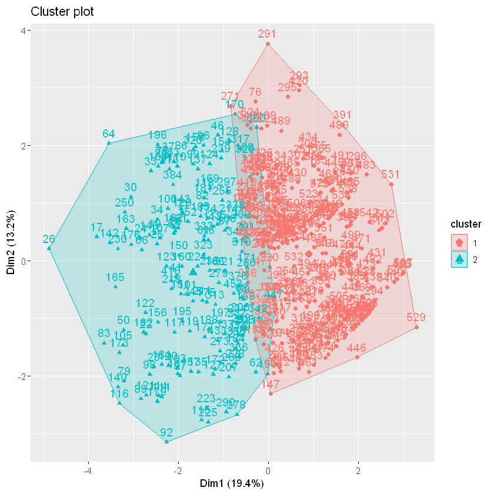

```
Precision :  0.6597979
Recall :  0.689959
```

0.674541428374797

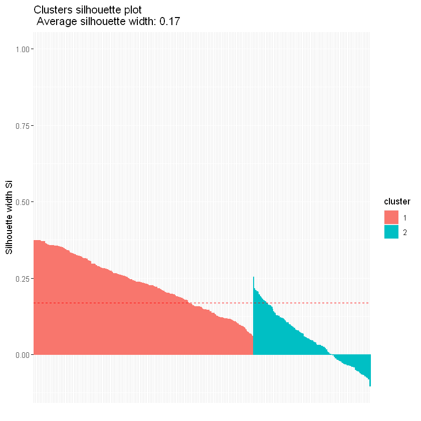

```r
# run kmeans clustering to find 2 clusters
kmeans.result <- kmeans(data,2)

# print the clusterng result
kmeans.result

## visualize clustering
install.packages("factoextra")
library(factoextra)
fviz_cluster(kmeans.result, data = data)

###Cluster Validation
library(cluster)
#average for each cluster
avg_sil <- silhouette(kmeans.result$cluster,dist(data))
fviz_silhouette(avg_sil)

#bcubed

L <- c(data2$price)
C <-(kmeans.result$cluster)
becubed_function(L,C)
Bcubed_score <- BCubed_metric(L, C, 0.5)
Bcubed_score
```

Let's analyze the results of the K-means clustering with 2 clusters:

### **2. Clustering Vector:**

- The clustering vector assigns each data point to either Cluster 1 or Cluster 2.
- You can observe the distribution of data points across clusters.

### **3. Within Cluster Sum of Squares (WSS):**

- **WSS for Cluster 1:** 2080.667
- **WSS for Cluster 2:** 2725.001
- **TOTAL** : 4805.668
- **Percentage of variance within clusters:** 13.3%
- Lower WSS values suggest tighter, more compact clusters; Cluster 1 is tighter and more compact than Cluster 2.

### **4. BCubed Metric:**

- **Precision:** 65.97% The precision of 0.6597979 means that around 65.97% of instances assigned to a cluster were correct.
- **Recall:** 68.99% The recall of 0.689959 indicates that about 68.99% of instances truly belonging to a cluster were correctly assigned.
- **Bcubed-Score:** 67.45% The Bcubed score of 0.674541428374797 combines precision and recall, reflecting an overall good clustering performance, with the balance influenced by the alpha parameter. Higher Bcubed scores generally indicate better clustering performance.
- These metrics measure the accuracy and completeness of the clustering result compared to the ground truth (class label; price in this case).

### **5. Visual Representation:**

- The clustering result is visualized using the `factoextra` package, showing how data points are distributed into two clusters.
- In Cluster plot we notice that cluster 1 has tighter, closer data points than cluster 2,

### **6. Silhouette Analysis:**

- The silhouette analysis provides an average silhouette width for each cluster. Higher values indicate better-defined clusters.The silhouette score and plot are used to evaluate the quality of a clustering solution produced by the k-means algorithm. The silhouette score measures the similarity of each point to its own cluster compared to other clusters, and the silhouette plot visualizes these scores for each sample. Since 0.17 was the average silhouette width; the similarity between each data point to its own cluster is very low.
- The cluster sizes indicate that Cluster 1 has 302 data points, while Cluster 2 has 161 data points. A higher silhouette width generally suggests better-defined clusters. In this case, Cluster 1 has an average silhouette width of 0.23, indicating a relatively good separation of data points within the cluster. On the other hand, Cluster 2 has a lower average silhouette width of 0.05, suggesting that the cohesion within this cluster is weaker, and data points may be less well-separated.

#### **Suggestions:**

- The clusters seem to capture distinct groups with different property specifications.
- We will consider trying another number of clusters and rerunning the analysis to find the optimal clustering solution.

## B. Clustering with K=4:

```
K-means clustering with 4 clusters of sizes 88, 154, 76, 145

Cluster means:
        area    bedrooms    bathrooms    stories      mainroad   guestroom
1  0.8268344  0.06112366 -0.009979944 -0.3837143  0.3698782737  1.35742621
2 -0.1669815 -0.87753712 -0.470945037 -0.8783141 -0.1551939501 -0.38411188
3  0.1173279  0.75549145  1.920638911  0.6132539 -0.0006231795 -0.03380771
4 -0.3859530  0.49892748 -0.500446803  0.8442755 -0.0593245388 -0.39814408
     basement hotwaterheating airconditioning    parking    prefarea
1  1.06400137     -0.10057661      0.36415259  0.3851669  0.93113616
2 -0.48402305     -0.08462356     -0.32986586 -0.1964014 -0.33559507
3  0.09357946      0.11101129      0.33992923  0.2772652 -0.03373919
4 -0.18072144      0.09273042     -0.04883247 -0.1704898 -0.19099423
  furnishingstatus
1      -0.33505375
```

[output cut: 62 more lines]

```
  cluster size ave.sil.width
1       1   88          0.09
2       2  154          0.19
3       3   76          0.05
4       4  145          0.11
```

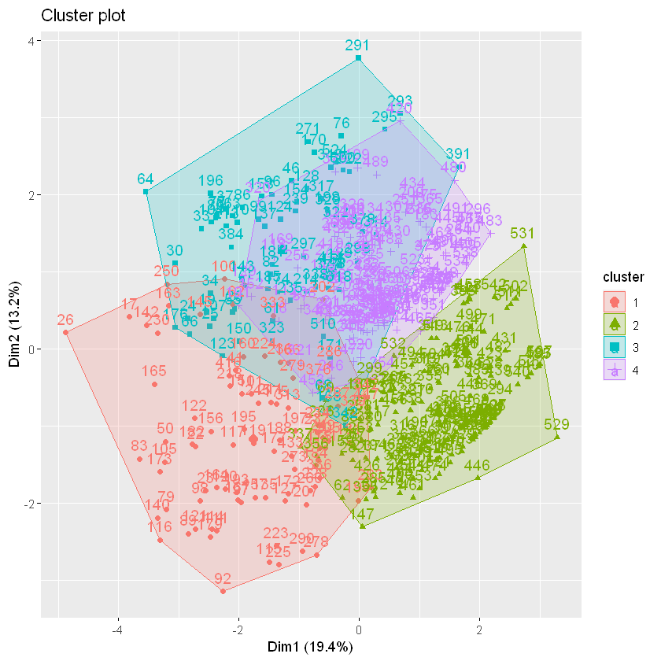

```
Precision :  0.6425107
Recall :  0.3405989
```

0.445196425645807

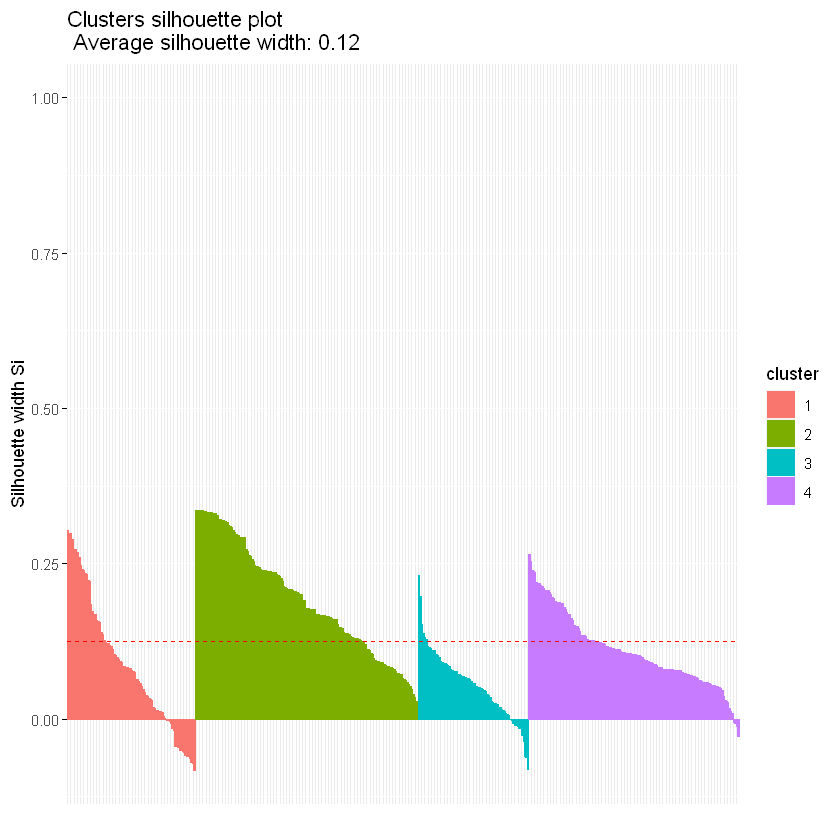

```r
# kmeans clustering to find 4 clusters
kmeans.result <- kmeans(data,4)
# print the clusterng result
kmeans.result
## visualize clustering
library(factoextra)
fviz_cluster(kmeans.result, data = data)

###Cluster Validation
library(cluster)
#average for each cluster
avg_sil <- silhouette(kmeans.result$cluster,dist(data))
fviz_silhouette(avg_sil)

#becubd

L <- c(data2$price)
C <-(kmeans.result$cluster)
becubed_function(L,C)
Bcubed_score <- BCubed_metric(L, C, 0.5)
Bcubed_score
```

let's analyze the results of the K-means clustering with 4 clusters based on the output:

### **2. Clustering Vector:**

- The clustering vector assigns each data point to one of the four clusters.
- Data points are distributed across clusters, indicating the diversity of property types in the dataset.

### **3. Within Cluster Sum of Squares (WSS):**

- **WSS for Cluster 1:** 947.7685
- **WSS for Cluster 2:** 1067.8061
- **WSS for Cluster 3:** 868.2525
- **WSS for Cluster 4:** 1196.2371
- **TOTAL**: 4080.0642
- **Percentage of variance within clusters:** 26.4%
- Lower WSS values suggest tighter, more compact clusters. All clusters have relatively low WSS, indicating reasonable compactness.

### **4. BCubed Metric:**

- **Precision:** 64.25% Around 64.25% of instances assigned to the same cluster belong to the same category.
- **Recall:** 34.06% About 34.06% of instances belonging to to the same category are assigned to the same cluster.
- **Bcubed-Score:** 44.52% The Bcubed score combines precision and recall, reflecting an overall clustering performance. The balance is influenced by the alpha parameter (0.5 in this case).

### **5. Visual Representation:**

- The clustering result is visualized using the `factoextra` package, showing how data points are distributed into four clusters.
- In the cluster plot we notice that cluster 3 and 4 have the highest similarities among the 4 clusters, although all clusters share some similarities as well, cluster 1 and 2 have some similarities but not as high as the similarity between 3 and 4.

### **6. Silhouette Analysis:**

- The average silhouette width for each cluster:
  - Cluster 1: 0.09
  - Cluster 2: 0.19
  - Cluster 3: 0.05
  - Cluster 4: 0.11
- The average silhouette width (0.12) suggests a low separation between clusters.
- Cluster 2 has the highest silhouette width, indicating better-defined boundaries, while Cluster 3 has the lowest, suggesting weaker cohesion.

#### **Suggestions:**

- It might be beneficial to further investigate and refine the clustering approach for improved performance.

## C. Clustering with K=8:

```
K-means clustering with 8 clusters of sizes 44, 20, 45, 28, 53, 111, 58, 104

Cluster means:
         area   bedrooms  bathrooms    stories    mainroad   guestroom
1 -0.05970918  0.4577756 -0.5004468  0.6495073  0.05839475 -0.09098171
2 -0.11974676  0.0645728  0.1810440  0.3739815  0.02101673 -0.05477151
3 -0.43543262  0.6547602  2.0235932  0.1524330 -0.35968535 -0.21704684
4  1.13127127  0.8125450  1.6089295  1.1259804  0.33428016  0.02109748
5  1.12225108 -0.4136222 -0.3718636 -0.8615066  0.43217498 -0.45308369
6 -0.41295034 -0.9594821 -0.5004468 -0.8956710 -0.30865070 -0.38131573
7  0.56314368  0.1378374  0.1653775 -0.2118233  0.43217498  2.20233083
8 -0.51310713  0.4498160 -0.5004468  0.7973095 -0.09495098 -0.45308369
     basement hotwaterheating airconditioning    parking    prefarea
1 -0.04558476       -0.212248       1.6426076 -0.3470235 -0.04805485
2 -0.23445049        4.701293      -0.4949692  0.3383068 -0.17861365
```

[output cut: 74 more lines]

```
  cluster size ave.sil.width
1       1   44          0.12
2       2   20          0.32
3       3   45          0.06
4       4   28          0.11
5       5   53          0.10
6       6  111          0.22
7       7   58          0.13
8       8  104          0.15
```

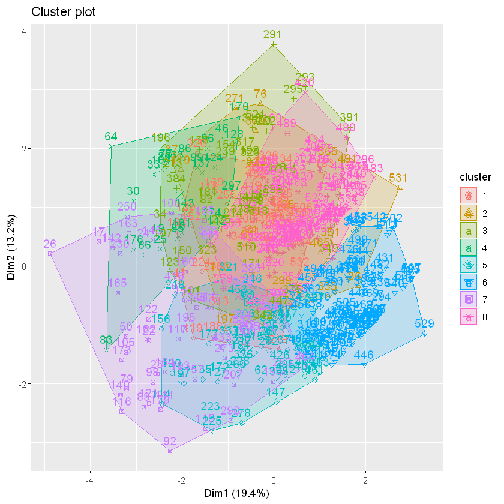

```
Precision :  0.6554283
Recall :  0.2118451
```

0.320197211050914

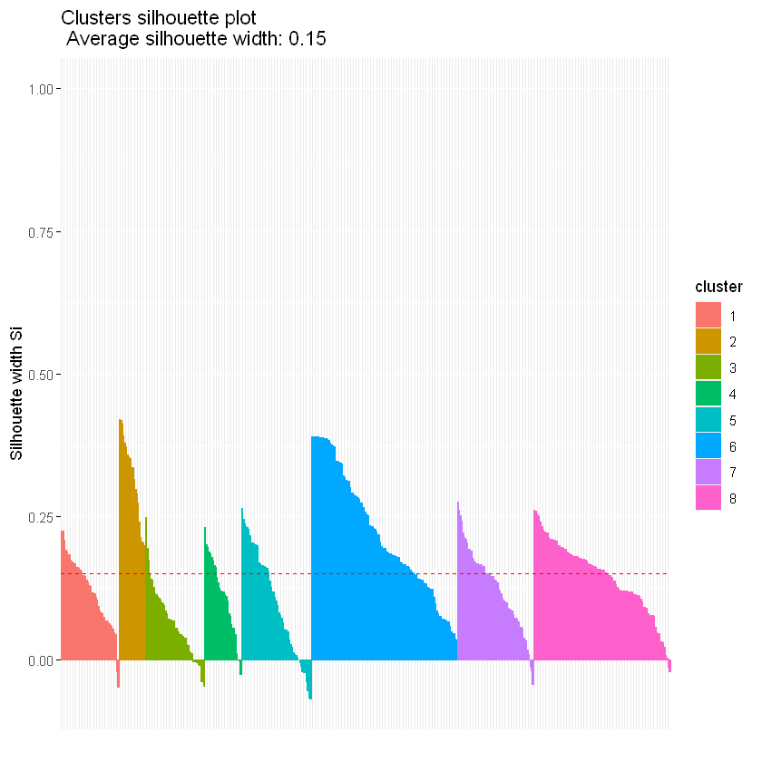

```r
# kmeans clustering to find 8 clusters
kmeans.result <- kmeans(data,8)
# print the clusterng result
kmeans.result
## visualize clustering
library(factoextra)
fviz_cluster(kmeans.result, data = data)

###Cluster Validation
library(cluster)
#average for each cluster
avg_sil <- silhouette(kmeans.result$cluster,dist(data))
fviz_silhouette(avg_sil)

#becubd

L <- c(data2$price)
C <-(kmeans.result$cluster)
becubed_function(L,C)
Bcubed_score <- BCubed_metric(L, C, 0.5)
Bcubed_score
```

Let's analyze the results of the K-means clustering with 8 clusters:

### **2. Clustering Vector:**

- The clustering vector assigns each data point to one of the eight clusters.
- Data points are distributed across clusters, reflecting the diversity of property types in the dataset.

### **4. BCubed Metric:**

- **Precision:** 65.54%
  - The precision of 0.6554283 indicates that approximately 65.54% of instances assigned to a cluster were correct. The precision score suggests that a relatively high proportion of instances assigned to clusters are correct.
- **Recall:** 21.18%
  - The recall of 0.2118451 indicates that about 21.18% of instances truly belonging to a cluster were correctly assigned. The recall score is lower, indicating that a smaller proportion of instances truly belonging to clusters are correctly assigned.
- **Bcubed-Score:** 32.02%
  - The Bcubed score of 0.320197211050914 combines precision and recall, reflecting an overall clustering performance. The balance between precision and recall is influenced by the alpha parameter (set to 0.5 in this case). A higher Bcubed score generally indicates better clustering performance. The Bcubed score, considering both precision and recall, is at 32.02%, suggesting a moderate overall clustering performance.

### **5. Visual Representation:**

- The clustering result is visualized using the `factoextra` package, showing how data points are distributed into eight clusters.
- The cluster plot may reveal patterns and separations between different clusters.
- we couldn't analyze the cluster plot because it is too interconnected and almost all clusters share similarities, which makes this clustering K the lowest performance of the three.

### **6. Silhouette Analysis:**

- The silhouette analysis provides an average silhouette width for each cluster, measuring how similar each point is to its own cluster compared to other clusters. Higher values indicate better-defined clusters.
- **Cluster 1:**
  - Size: 44
  - Average Silhouette Width: 0.12
  - Indicates a low level of separation and cohesion within this cluster.
- **Cluster 2:**
  - Size: 20
  - Average Silhouette Width: 0.32
  - Suggests a higher level of separation and cohesion within this cluster compared to other avg.sil.wid in other clusters, indicating well-defined and distinct properties.
- **Cluster 3:**
  - Size: 45
  - Average Silhouette Width: 0.06
  - Indicates a lower level of separation and cohesion within this cluster compared to others.
- **Cluster 4:**
  - Size: 28
  - Average Silhouette Width: 0.11
  - Shows a low level of separation and cohesion within this cluster.
- **Cluster 5:**
  - Size: 53
  - Average Silhouette Width: 0.10
  - Indicates a low level of separation and cohesion within this cluster.
- **Cluster 6:**
  - Size: 111
  - Average Silhouette Width: 0.22
  - Suggests a higher level of separation and cohesion within this cluster compared to other avg.sil.wid in other clusters, indicating well-defined and distinct properties.
- **Cluster 7:**
  - Size: 58
  - Average Silhouette Width: 0.13
  - Indicates a modelowrate level of separation and cohesion within this cluster.
- **Cluster 8:**
  - Size: 104
  - Average Silhouette Width: 0.15
  - Suggests a low level of separation and cohesion within this cluster.
- **Overall Analysis:**
  - The average silhouette width measures the overall quality of the clustering solution. In this case, the average silhouette width is relatively low (0.15), suggesting lower separation and cohesion in the overall clustering result.
  - Clusters 2, 6, and 8 stand out with higher silhouette widths, indicating moderately-defined and distinct groups of properties.
  - Clusters 3 and 5 have lower silhouette widths, suggesting lower cohesion and separation within these clusters.

## **Clustering Summary**

### Cluster C (k=8) Analysis:

- **Cluster Means:**
  - Various clusters with above-average values for different sets of features.
- **BCubed Metric:**
  - Precision: 65.54%
  - Recall: 21.18%
  - Bcubed-Score: 32.02%
- **Silhouette Analysis:**
  - Average Silhouette Width: 0.15 (lower overall separation and cohesion)
  - Some clusters (2, 6, 8) have higher silhouette widths, indicating moderately-defined groups.
  - Clusters 3 and 5 have lower silhouette widths, suggesting lower cohesion.

### Conclusion:

- The choice of the number of clusters (k) influences the granularity and specificity of the clustering result.
- Cluster A (k=2) appears to strike the best performance, providing the highest avg.sil.width, the lowest similaritiy between its clusters, and the best BCubed precision and recall values.

### **Evaluation and Comparison:**

Classification (Figure 1)

|  | 90% Training Set & 10% Testing Set |  |  | 80% Training Set & 20% Testing Set |  |  | 70% Training Set & 30% Testing Set |  |  |
| --- | --- | --- | --- | --- | --- | --- | --- | --- | --- |
|  | IG | IG ratio | Gini Index | IG | IG ratio | Gini Index | IG | IG ratio | Gini Index |
| Accuracy | 80.85% | 68.09% | 76.59% | 68.82% | 77.42% | 76.34% | 70.5% | 76.26% | 76.26% |
| Precision | 80.56% | 78.57% | 83.33% | 62.12% | 75% | 78.04% | 65.35% | 73.49% | 70.15% |
| Sensitivity | 93.55% | 70.97% | 80.64% | 91.11% | 80% | 71.11% | 91.67% | 84.72% | 78.33% |
| Specificity | 56.25% | 62.5% | 68.75% | 47.92% | 75% | 81.25% | 47.76% | 67.16% | 74.68% |

Clustering (Figure 2)

|  | K=2 | K=4 | K=8 |
| --- | --- | --- | --- |
| Average Silhouette width | 0.17 | 0.12 | 0.15 |
| Total within-cluster sum of square | 4805.668 | 4080.0642 | 3140.1555 |
| BCubed Precision | 65.97% | 64.25% | 65.54% |
| BCubed Recall | 68.99% | 34.06% | 21.18% |

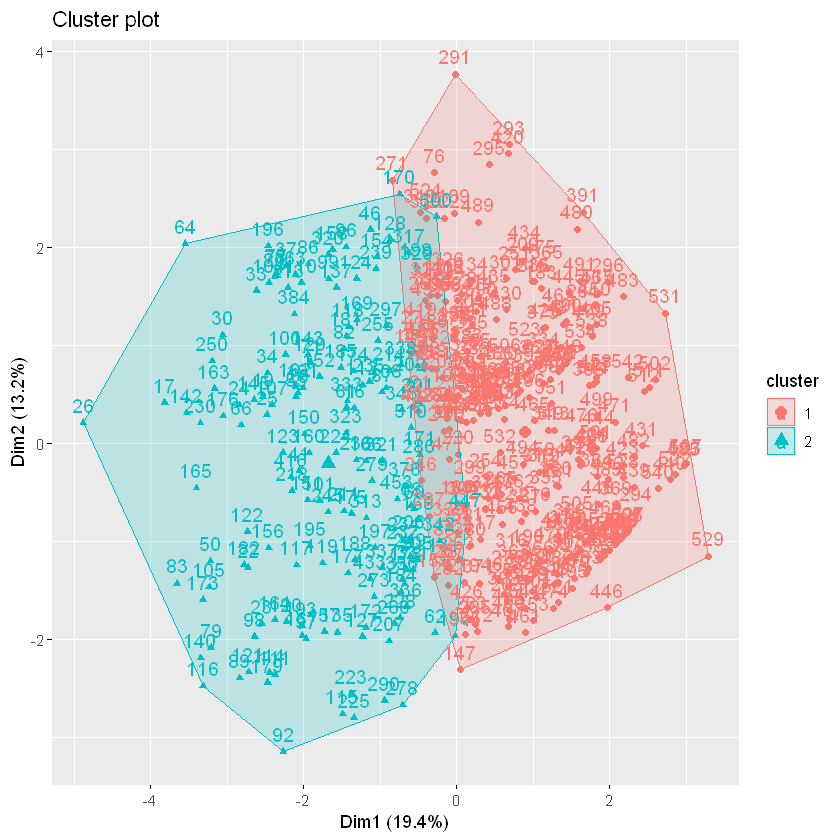

(Figure 3)

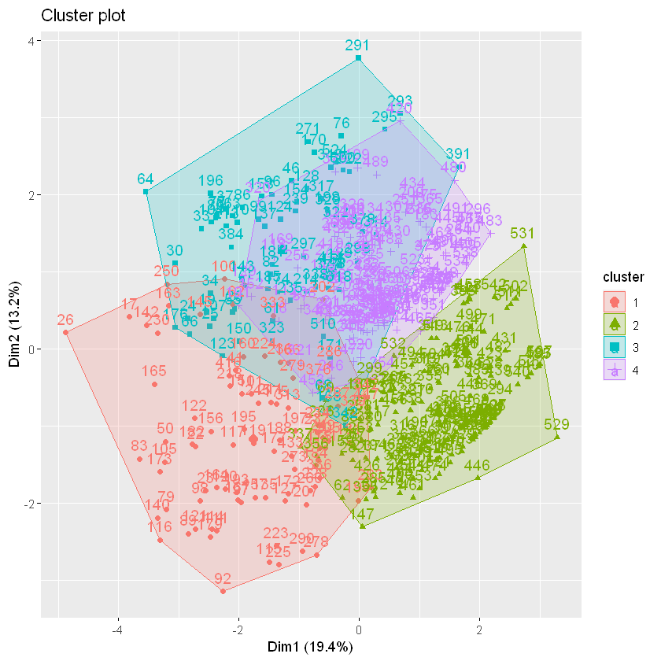

(Figure 4)

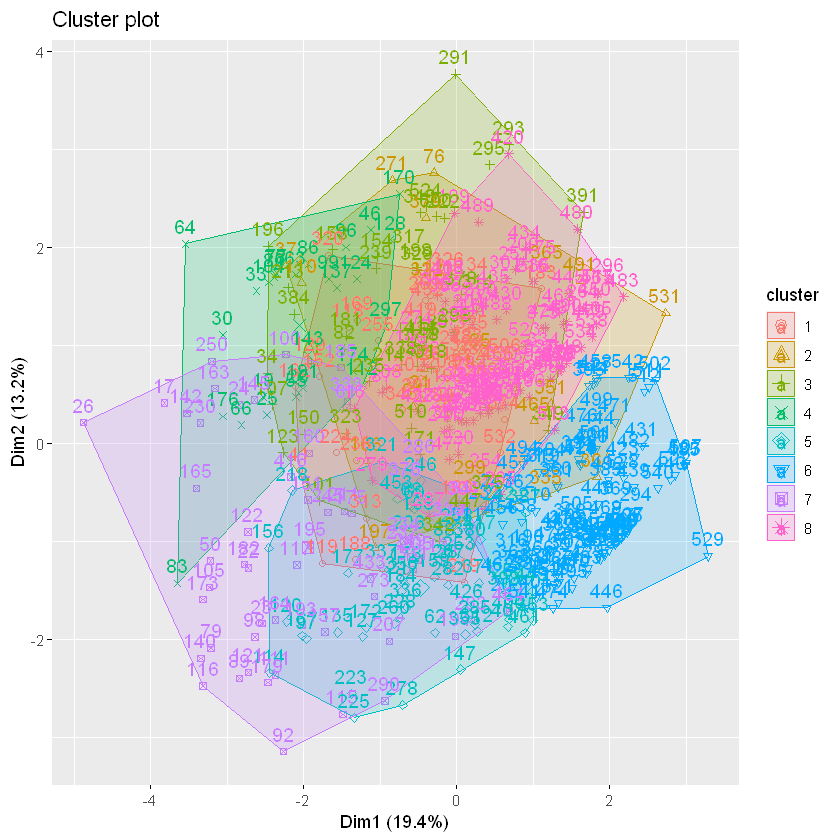

(Figure 5)

### **Findings:**

We have selected a housing prices dataset that represents houses attributes to help stakeholders know the predictions of house prices that they look for based on the houses' characteristics which can improve the proccess of either looking for a house, or trying to sell one with no time.

To provide the best accurate result possible we have applied some preprocessing techniques that can improve the efficiency of our dataset by making the dataset purer to produce an excellent model hopfully. Additionaly, We performed some data visualization techniques such as boxplot, histogram, barplot, and scatterplot to illustrate the data which can help us understand our data to decide which preprocessing techniques are the most appropriate. Based on the boxplots, we have removed the outliers in each attribute which can badly affect the results. Also, we applied data transformation on our attribute by encoding some of the numerical attributes and the categorical as well, discretized the 'price' which is the class label into 'high' and 'low' intervals to facilitate handling the data. Moreover, we performed feature selection on our dataset to decide which features give the best accuracy which would be used during data mining tasks, the features selected were all the 12 features which we have used to perform our classification and clustering techniques.

Accordingly, we enforced the data mining tasks which are classification and clustering.

#### **For Clustering:**

we used K-means algorithm with 3 different K that we have chosen randomly to find the optimal number of clusters, we calculated the average silhouette width(ASW), the total within sum of squares(TWSS), the BCubed metrics: precision, and recall for each K, and we concluded the following results:

In **K=2**:

- the average sillhouette width(ASW) was : 0.17 **(see Figure 2)**, which was our highest ASW but wasn't considered high enough for clustering in general.
- the Total Within Cluster Sum of Squares (TWSS) was 4805.668 which was unfortunately the highest TWSS among the three K's and the best should be the least values of TWSS.
- The BCubed Precision was 65.97% which was quite good and actually the best result out of the three.
- The BCubed Recall was 68.99% which was also the highest value and a good value overall in Clustering.
- For Visualization,The red cluster was a bit tighter than the blue cluster but The plot was the best plot among the K's having the most separated clusters **(see Figure 3)**.

Overall **K=2** Clusters Performance was moderately good, The highest Performance among the K's.

In **K=4**:

- the ASW was : 0.12 **(see Figure 2)** which was the lowest among them.
- the TWSS was : 4080.0642 which was the second least, moderate but could be better.
- the BCubed Precision was 64.25% which is the lowest value among the K's but it wasn't bad at all its moderately good.
- the Bcubed Recall was 34.06% a very low value but not the lowest, could be improved.
- For visualisation, we can see a little bit of overlap between the clusters which makes it less efficient, not all the clusters were tight enough **(see Figure 4)**.

overall **K=4** is the least likely to be chosen as the best K.

In **K=8**:

- the ASW was : 0.15 **(see Figure 2)** which was pretty close to K=2 : 0.17, the second best value among the K's.
- the TWSS was : 3140.1555 which was the least value making it the best value compared to the other two K's.
- The BCubed Precision was: 65.54% which was very close to K=2 value: 65.97% making it rank the second after K=2's precision.
- The BCubed Recall it was : 21.18% which was the lowest value among the K's.
- For Visualization, we couldn't analyze the cluster plot because it is too interconnected and almost all clusters share similarities, which makes this clustering K the lowest performance of the three in visualization **(see Figure 5)**.

Overall **K=8** had mostly good values compared to **K=4** but less efficient than **K=2**.

In Conclusion, we found that the best K for clustering is **K=2** Because it had the highest Average silhouette width being 0.17 and the BCubed metrics: precision(65.97%) and recall(68.99%), also it had the best graphical representation among the three of them. Although K=8 had the lowest total within sum of squares(3140.1555) and a high BCubed Precision(65.54%) and Average silhouette width(0.15), but it had a very low BCubed Recall(21.18%) compared to K=2 and K=4 so we finally chose K=2 as the best K for Clustering **(see Figure 2)**.

#### **Classification VS. Clustering:**

Based on what we applied of algorithms on both classification and clustering we found that both were very helpful in predicting housing prices, which lead to reach our goal to help stakeholders like real estate agents, and even non-real estate agent people that are interested in housing prices to accurately predict the price of a certain house based on multiple characteristics of the house.

However, we determined the best data mining technique for our dataset which is **Classification** since it has a higher accuracy compared to the clustering and the reason for that is in supervised learning(Classification) it requires the class label provided in advance unlike unsupervised learning(Clustering) which only predicts which datapoints are closer to each other without knowing what the class label is. Also, in Clustering we noticed that the Average silhouette width for all the K's were on the low side and the total WSS was high for all of them as well, the only acceptable values were only for BCubed precision which also werent high but only moderate, and low values for BCubed Recall as well.

### References

[1] R. Mylonakis, “DPBBM: BCubed_metric.r,” R package version 1.1.1, Dec. 2018. [Online]. Available: https://rdrr.io/cran/DPBBM/src/R/BCubed_metric.r . [Accessed: Nov. 5, 2023].

[2] A. Author, "Classification," [Online]. Available: 4 IT326 - Ch6 – Classification.pdf (Slide 18). [Accessed: Nov. 1, 2023].

[3] M. Kuhn et al., “confusionMatrix function - caret package,” [Online]. Available: https://www.rdocumentation.org/packages/caret/versions/6.0-86/topics/confusionMatrix [Accessed: Nov. 4, 2023].

[4] A. Author, "Title of the document," RPubs, [Online]. Available: https://rpubs.com/kjmazidi/195428. [Accessed: Nov. 3, 2023].

[5] A. Author, "Title of the document," RPubs, [Online]. Available: https://rpubs.com/camguild/803096. [Accessed: Nov. 3, 2023].

[6] "Feature Selection with the caret R Package," GeeksforGeeks, [Online]. Available: https://www.geeksforgeeks.org/feature-selection-with-the-caret-r-package/ .[Accessed: Oct. 5, 2023].